# ml-swat-sklearn-vy34-05-2.0

The purpose of the demo is to show a sample of ML capabilities in Viya VDMML using the jupyter interface. We create a **ML pipeline to train and compare models for an example supervised learning problem : churn detection**.

In this demo we will

1. First read data into a into a Pandas data frame on the client laptop
2. Then uploaded to the CAS server(s)
3. We'll then do some simple Data Manipulation steps to show SQL capabilities
4. Build Classification models (CAS & sklearn)
5. We'll do some Automated Model Training/Tuning
6. Assess Models
7. Compare their performance
8. Score Data in Batch and Save the artifacts to score in real time.

```python
import swat,pygal
#from _config import container_18wk47_login, container_19wk21_login,container_xl_19wk21_login
from _config import container_19wk21_login
from swat.render import render_html
import numpy as np
import warnings
warnings.simplefilter(action='ignore', category=FutureWarning)
import pandas as pd
pd.set_option('display.float_format', lambda x: '%.2f' % x)
from matplotlib import pyplot as plt
from IPython.display import HTML
%matplotlib inline
from plotnine import *
import os, time
#os.environ['CAS_CLIENT_SSL_CA_LIST']=r'/ext_str/beast_trustfiles/nBeast_trustfiles/trustedcerts.pem'
from IPython.display import IFrame
%reload_ext autoreload
%autoreload 2
```

```python
#Connect to the CAS Server

host = container_19wk21_login()[2]
user = container_19wk21_login()[0]
pswd = container_19wk21_login()[1]
conn = swat.CAS(host,5570,user,pswd)

# conn.about()

# conn = swat.CAS(login()[2],8777,login()[0],login()[1],protocol="http")
conn.setsessopt(caslib="casuser")
```

```
NOTE: 'CASUSER(sasdemo)' is now the active caslib.
```

elapsed 0.000768s · user 0.000725s · mem 0.23MB

Load Data into pandas and check out the columns

```python
#Load the data set into a pandas dataframe
churn_df=pd.read_csv('churn.csv')
#Clean print column names
for i in churn_df.columns : print(i)
```

```
Account Length
VMail Message
Day Mins
Eve Mins
Night Mins
Intl Mins
CustServ Calls
Churn
Int'l Plan
VMail Plan
Day Calls
Day Charge
Eve Calls
Eve Charge
Night Calls
Night Charge
Intl Calls
Intl Charge
State
Area Code
Phone
```

Clearly, we want to rename some of these columns

```python
#remove/replace special characters and white spaces
churn_df.columns = [i.replace(' ','_').replace("'",'').lower() for i in churn_df.columns]
#Check out how the resultant dataset look like
churn_df.head()
```

|  | account_length | vmail_message | day_mins | eve_mins | night_mins | intl_mins | custserv_calls | churn | intl_plan | vmail_plan | ... | day_charge | eve_calls | eve_charge | night_calls | night_charge | intl_calls | intl_charge | state | area_code | phone |
| --- | --- | --- | --- | --- | --- | --- | --- | --- | --- | --- | --- | --- | --- | --- | --- | --- | --- | --- | --- | --- | --- |
| 0 | 128 | 25 | 265.10 | 197.40 | 244.70 | 10.00 | 1 | 0 | 0 | 1 | ... | 45.07 | 99 | 16.78 | 91 | 11.01 | 3 | 2.70 | KS | 415 | 382-4657 |
| 1 | 107 | 26 | 161.60 | 195.50 | 254.40 | 13.70 | 1 | 0 | 0 | 1 | ... | 27.47 | 103 | 16.62 | 103 | 11.45 | 3 | 3.70 | OH | 415 | 371-7191 |
| 2 | 137 | 0 | 243.40 | 121.20 | 162.60 | 12.20 | 0 | 0 | 0 | 0 | ... | 41.38 | 110 | 10.30 | 104 | 7.32 | 5 | 3.29 | NJ | 415 | 358-1921 |
| 3 | 84 | 0 | 299.40 | 61.90 | 196.90 | 6.60 | 2 | 0 | 1 | 0 | ... | 50.90 | 88 | 5.26 | 89 | 8.86 | 7 | 1.78 | OH | 408 | 375-9999 |
| 4 | 75 | 0 | 166.70 | 148.30 | 186.90 | 10.10 | 3 | 0 | 1 | 0 | ... | 28.34 | 122 | 12.61 | 121 | 8.41 | 3 | 2.73 | OK | 415 | 330-6626 |

5 rows × 21 columns

Usually we would load data from database or the server side - or some distributed file system. For this example **Load data into CAS from the client** and examine the resulting CASResults Object

```python
out=conn.upload(churn_df,casout=dict(name='churn',caslib='casuser',replace=True))
out
```

```
NOTE: Cloud Analytic Services made the uploaded file available as table CHURN in caslib CASUSER(sasdemo).
NOTE: The table CHURN has been created in caslib CASUSER(sasdemo) from binary data uploaded to Cloud Analytic Services.
```

**§ caslib**

CASUSER(sasdemo)

**§ tableName**

CHURN

**§ casTable**

CASTable('CHURN', caslib='CASUSER(sasdemo)')

elapsed 0.0187s · user 0.0268s · sys 0.00311s · mem 18.1MB

Check out the CAS Table

```python
out=out.casTable
render_html(out.fetch(to=5))
```

| Selected Rows from Table CHURN |  |  |  |  |  |  |  |  |  |  |  |  |  |  |  |  |  |  |  |  |
| --- | --- | --- | --- | --- | --- | --- | --- | --- | --- | --- | --- | --- | --- | --- | --- | --- | --- | --- | --- | --- |
| 128 | 25 | 265.1 | 197.4 | 244.7 | 10 | 1 | 0 | 0 | 1 | 110 | 45.07 | 99 | 16.78 | 91 | 11.01 | 3 | 2.7 | KS | 415 | 382-4657 |
| 107 | 26 | 161.6 | 195.5 | 254.4 | 13.7 | 1 | 0 | 0 | 1 | 123 | 27.47 | 103 | 16.62 | 103 | 11.45 | 3 | 3.7 | OH | 415 | 371-7191 |
| 137 | 0 | 243.4 | 121.2 | 162.6 | 12.2 | 0 | 0 | 0 | 0 | 114 | 41.38 | 110 | 10.3 | 104 | 7.32 | 5 | 3.29 | NJ | 415 | 358-1921 |
| 84 | 0 | 299.4 | 61.9 | 196.9 | 6.6 | 2 | 0 | 1 | 0 | 71 | 50.9 | 88 | 5.26 | 89 | 8.86 | 7 | 1.78 | OH | 408 | 375-9999 |
| 75 | 0 | 166.7 | 148.3 | 186.9 | 10.1 | 3 | 0 | 1 | 0 | 113 | 28.34 | 122 | 12.61 | 121 | 8.41 | 3 | 2.73 | OK | 415 | 330-6626 |

```python
out.dtypes
```

```
account_length     double
vmail_message      double
day_mins           double
eve_mins           double
night_mins         double
intl_mins          double
custserv_calls     double
churn              double
intl_plan          double
vmail_plan         double
day_calls          double
day_charge         double
eve_calls          double
eve_charge         double
night_calls        double
night_charge       double
intl_calls         double
intl_charge        double
state             varchar
area_code          double
phone             varchar
dtype: object
```

We notice two things that ought to be done here. The data type for `churn` and `area_code` variables should not be double. Let's change that by using some SQL on the in memory table.

```python
#Enable SQL actions - for distributed SQL
conn.loadactionset('fedSQL')

#programmatically build query
col_list= [i for i in out.columns if i not in ('area_code','churn','intl_plan','vmail_plan')]
cas_lib='casuser'
option_params='{options replace=true}'
query = """create table {}.churn {} as select {},
cast(intl_plan as char) as intl_plan,
cast(vmail_plan as char) as vmail_plan,
cast(area_code as varchar) as area_code,
cast(churn as varchar) as churn
from casuser.churn """.format(cas_lib,
                              option_params,
                              col_list).replace('[','').replace(']','').replace("'",'')
print(query)
```

```
NOTE: Added action set 'fedSQL'.
create table casuser.churn {options replace=true} as select account_length, vmail_message, day_mins, eve_mins, night_mins, intl_mins, custserv_calls, day_calls, day_charge, eve_calls, eve_charge, night_calls, night_charge, intl_calls, intl_charge, state, phone,
cast(intl_plan as char) as intl_plan,
cast(vmail_plan as char) as vmail_plan,
cast(area_code as varchar) as area_code,
cast(churn as varchar) as churn
from casuser.churn
```

```python
#execute query and check the results
conn.fedsql.execdirect(query) # run the query
out = conn.CASTable('CHURN', caslib ='casuser') #get the results
render_html(out.fetch(to=5)) #view the results
```

```
NOTE: Table CHURN was created in caslib CASUSER(sasdemo) with 3333 rows returned.
```

| Selected Rows from Table CHURN |  |  |  |  |  |  |  |  |  |  |  |  |  |  |  |  |  |  |  |  |
| --- | --- | --- | --- | --- | --- | --- | --- | --- | --- | --- | --- | --- | --- | --- | --- | --- | --- | --- | --- | --- |
| 128 | 25 | 265.1 | 197.4 | 244.7 | 10 | 1 | 110 | 45.07 | 99 | 16.78 | 91 | 11.01 | 3 | 2.7 | KS | 382-4657 | 0 | 1 | 415 | 0 |
| 107 | 26 | 161.6 | 195.5 | 254.4 | 13.7 | 1 | 123 | 27.47 | 103 | 16.62 | 103 | 11.45 | 3 | 3.7 | OH | 371-7191 | 0 | 1 | 415 | 0 |
| 137 | 0 | 243.4 | 121.2 | 162.6 | 12.2 | 0 | 114 | 41.38 | 110 | 10.3 | 104 | 7.32 | 5 | 3.29 | NJ | 358-1921 | 0 | 0 | 415 | 0 |
| 84 | 0 | 299.4 | 61.9 | 196.9 | 6.6 | 2 | 71 | 50.9 | 88 | 5.26 | 89 | 8.86 | 7 | 1.78 | OH | 375-9999 | 1 | 0 | 408 | 0 |
| 75 | 0 | 166.7 | 148.3 | 186.9 | 10.1 | 3 | 113 | 28.34 | 122 | 12.61 | 121 | 8.41 | 3 | 2.73 | OK | 330-6626 | 1 | 0 | 415 | 0 |

```python
# To save the file to the filesystem
#conn.table.save(table='CHURN', name='churn_opt.csv')
```

**Quick Side note** :- Nothing stops you from doing this - You can get fancy and write your own python helpers for anything on CAS like the example below which custom combines two actions together:-

```
def _load_actionset_not_loaded(action_set='whatsavailable'):
"""Check the action sets, if the action set asked for is available, load it. If it is already loaded - print that message.If its not available - show all action sets available"""
    loaded_action_sets=conn.actionsetinfo(all=True).setinfo[['actionset','loaded']]
    if len(loaded_action_sets[(loaded_action_sets['actionset']==action_set) &
                          (loaded_action_sets['loaded']==1)])>0:
        print('{} action set was already loaded'. format(action_set))
    elif len(loaded_action_sets[(loaded_action_sets['actionset']==action_set)])>0:
        print('You are licensed for that action set')
        conn.loadactionset(action_set)
        print('{} action set was loaded'.format(action_set))
    else:
        print('Cant recognize actionset name')
        print('Here is a list of all possible action sets')
        return conn.actionsetinfo(all=True).setinfo
_load_actionset_not_loaded('test')
```

**Explore Data**

Next we can do a quick exploration by performing group-bys

```python
grpsumm=out.groupby('churn').summary()
comb_group_summ = grpsumm.concat_bygroups()
combined_summary = comb_group_summ['Summary']
combined_summary.sort_values(by=['Column','CHURN'])
```

Descriptive Statistics for CHURN

| CHURN | Column | Min | Max | N | NMiss | Mean | Sum | Std | StdErr | Var | USS | CSS | CV | TValue | ProbT | Skewness | Kurtosis |
| --- | --- | --- | --- | --- | --- | --- | --- | --- | --- | --- | --- | --- | --- | --- | --- | --- | --- |
| 0 | account_length | 1.00 | 243.00 | 2850.00 | 0.00 | 100.79 | 287262.00 | 39.88 | 0.75 | 1590.60 | 33485820.00 | 4531624.69 | 39.57 | 134.92 | 0.00 | 0.09 | -0.13 |
| 1 | account_length | 1.00 | 225.00 | 483.00 | 0.00 | 102.66 | 49587.00 | 39.47 | 1.80 | 1557.71 | 5841645.00 | 750815.66 | 38.44 | 57.17 | 0.00 | 0.14 | 0.06 |
| 0 | custserv_calls | 0.00 | 8.00 | 2850.00 | 0.00 | 1.45 | 4132.00 | 1.16 | 0.02 | 1.35 | 9850.00 | 3859.32 | 80.28 | 66.50 | 0.00 | 0.89 | 1.21 |
| 1 | custserv_calls | 0.00 | 9.00 | 483.00 | 0.00 | 2.23 | 1077.00 | 1.85 | 0.08 | 3.43 | 4057.00 | 1655.49 | 83.11 | 26.44 | 0.00 | 0.70 | -0.10 |
| 0 | day_calls | 0.00 | 163.00 | 2850.00 | 0.00 | 100.28 | 285807.00 | 19.80 | 0.37 | 392.09 | 29778681.00 | 1117052.49 | 19.75 | 270.37 | 0.00 | -0.06 | 0.13 |
| 1 | day_calls | 0.00 | 165.00 | 483.00 | 0.00 | 101.34 | 48945.00 | 21.58 | 0.98 | 465.80 | 5184375.00 | 224513.66 | 21.30 | 103.19 | 0.00 | -0.35 | 0.73 |
| 0 | day_charge | 0.00 | 53.65 | 2850.00 | 0.00 | 29.78 | 84874.20 | 8.53 | 0.16 | 72.78 | 2734925.83 | 207336.41 | 28.65 | 186.36 | 0.00 | -0.23 | -0.00 |
| 1 | day_charge | 0.00 | 59.64 | 483.00 | 0.00 | 35.18 | 16989.97 | 11.73 | 0.53 | 137.59 | 663954.35 | 66316.50 | 33.35 | 65.91 | 0.00 | -0.20 | -0.81 |
| 0 | day_mins | 0.00 | 315.60 | 2850.00 | 0.00 | 175.18 | 499250.90 | 50.18 | 0.94 | 2518.20 | 94631000.61 | 7174347.57 | 28.65 | 186.36 | 0.00 | -0.23 | -0.00 |
| 1 | day_mins | 0.00 | 350.80 | 483.00 | 0.00 | 206.91 | 99939.50 | 69.00 | 3.14 | 4760.70 | 22973544.67 | 2294655.10 | 33.35 | 65.91 | 0.00 | -0.20 | -0.81 |
| 0 | eve_calls | 0.00 | 170.00 | 2850.00 | 0.00 | 100.04 | 285110.00 | 19.96 | 0.37 | 398.34 | 29656870.00 | 1134865.75 | 19.95 | 267.59 | 0.00 | -0.07 | 0.25 |
| 1 | eve_calls | 48.00 | 168.00 | 483.00 | 0.00 | 100.56 | 48571.00 | 19.72 | 0.90 | 389.06 | 5071881.00 | 187528.95 | 19.61 | 112.05 | 0.00 | 0.03 | -0.06 |
| 0 | eve_charge | 0.00 | 30.75 | 2850.00 | 0.00 | 16.92 | 48218.89 | 4.27 | 0.08 | 18.27 | 867874.91 | 52063.91 | 25.27 | 211.29 | 0.00 | -0.04 | 0.03 |
| 1 | eve_charge | 6.03 | 30.91 | 483.00 | 0.00 | 18.05 | 8720.55 | 4.40 | 0.20 | 19.33 | 166767.05 | 9317.79 | 24.35 | 90.25 | 0.00 | 0.03 | -0.09 |
| 0 | eve_mins | 0.00 | 361.80 | 2850.00 | 0.00 | 199.04 | 567273.40 | 50.29 | 0.94 | 2529.30 | 120117952.30 | 7205983.76 | 25.27 | 211.29 | 0.00 | -0.04 | 0.03 |
| 1 | eve_mins | 70.90 | 363.70 | 483.00 | 0.00 | 212.41 | 102594.10 | 51.73 | 2.35 | 2675.88 | 23081801.85 | 1289774.20 | 24.35 | 90.24 | 0.00 | 0.03 | -0.09 |
| 0 | intl_calls | 0.00 | 19.00 | 2850.00 | 0.00 | 4.53 | 12919.00 | 2.44 | 0.05 | 5.96 | 75551.00 | 16989.40 | 53.87 | 99.10 | 0.00 | 1.26 | 2.81 |
| 1 | intl_calls | 1.00 | 20.00 | 483.00 | 0.00 | 4.16 | 2011.00 | 2.55 | 0.12 | 6.51 | 11511.00 | 3138.08 | 61.28 | 35.86 | 0.00 | 1.71 | 4.88 |
| 0 | intl_charge | 0.00 | 5.10 | 2850.00 | 0.00 | 2.74 | 7818.70 | 0.75 | 0.01 | 0.57 | 23060.05 | 1610.20 | 27.40 | 194.81 | 0.00 | -0.29 | 0.69 |
| 1 | intl_charge | 0.54 | 5.40 | 483.00 | 0.00 | 2.89 | 1395.65 | 0.75 | 0.03 | 0.57 | 4306.93 | 274.14 | 26.10 | 84.21 | 0.00 | 0.02 | -0.00 |
| 0 | intl_mins | 0.00 | 18.90 | 2850.00 | 0.00 | 10.16 | 28952.80 | 2.78 | 0.05 | 7.75 | 316217.32 | 22089.38 | 27.41 | 194.77 | 0.00 | -0.29 | 0.69 |
| 1 | intl_mins | 2.00 | 20.00 | 483.00 | 0.00 | 10.70 | 5168.10 | 2.79 | 0.13 | 7.80 | 59059.19 | 3760.52 | 26.10 | 84.19 | 0.00 | 0.02 | 0.00 |
| 0 | night_calls | 33.00 | 175.00 | 2850.00 | 0.00 | 100.06 | 285166.00 | 19.51 | 0.37 | 380.49 | 29617236.00 | 1084026.33 | 19.49 | 273.84 | 0.00 | 0.03 | -0.02 |
| 1 | night_calls | 49.00 | 158.00 | 483.00 | 0.00 | 100.40 | 48493.00 | 19.95 | 0.91 | 398.03 | 5060527.00 | 191849.88 | 19.87 | 110.60 | 0.00 | 0.06 | -0.37 |
| 0 | night_charge | 1.04 | 17.77 | 2850.00 | 0.00 | 9.01 | 25667.31 | 2.30 | 0.04 | 5.29 | 246229.85 | 15068.16 | 25.54 | 209.06 | 0.00 | 0.02 | 0.10 |
| 1 | night_charge | 2.13 | 15.97 | 483.00 | 0.00 | 9.24 | 4460.76 | 2.12 | 0.10 | 4.50 | 43365.98 | 2168.51 | 22.97 | 95.69 | 0.00 | -0.01 | -0.08 |
| 0 | night_mins | 23.20 | 395.00 | 2850.00 | 0.00 | 200.13 | 570379.60 | 51.11 | 0.96 | 2611.72 | 121592693.18 | 7440802.62 | 25.54 | 209.06 | 0.00 | 0.02 | 0.10 |
| 1 | night_mins | 47.40 | 354.90 | 483.00 | 0.00 | 205.23 | 99126.90 | 47.13 | 2.14 | 2221.50 | 21414744.45 | 1070764.53 | 22.97 | 95.70 | 0.00 | -0.01 | -0.08 |
| 0 | vmail_message | 0.00 | 51.00 | 2850.00 | 0.00 | 8.60 | 24523.00 | 13.91 | 0.26 | 193.58 | 762505.00 | 551495.34 | 161.69 | 33.02 | 0.00 | 1.17 | -0.29 |
| 1 | vmail_message | 0.00 | 48.00 | 483.00 | 0.00 | 5.12 | 2471.00 | 11.86 | 0.54 | 140.66 | 80441.00 | 67799.51 | 231.83 | 9.48 | 0.00 | 2.04 | 2.56 |

Or, if you prefer visually scanning through data here's an example of a neat plot for visualization or you could simply get a pandas barplot

```python
# Hand Crafted Metric for Feature Visualization
radar_chart=pygal.Radar(style=pygal.style.DefaultStyle,include_x_axis=False)
radar_chart.title='Quick Feature Comparison - By Group Differences - Sq.Logged Mean Values'
radar_chart.x_labels=sorted(list(combined_summary['Column'].unique()))
radar_chart.add('Non-Churners',list(round(np.log(grpsumm['ByGroup1.Summary'][['Column','Mean']]
                                    .sort_values(by=['Column'])['Mean'])**2,1)))
radar_chart.add('Churners',list(round(np.log(grpsumm['ByGroup2.Summary'][['Column','Mean']]
                                    .sort_values(by=['Column'])['Mean'])**2,1)))
radar_chart.render_to_file('charts/radar.svg')
IFrame(width=800, height=800, frameBorder=0, src="charts/radar.svg")
```

[interactive chart not shown]

```python
# for i in comb_group_summ['Summary']['Column'].unique():
#     plt.figure()
#     combined_summary[combined_summary['Column']==i]['Mean'].plot(kind='barh', color='teal').set_title(i);
#     plt.show()
```

You can also get a traditional `ggplot` viz going, by sampling from the server side data (if you data is too big)

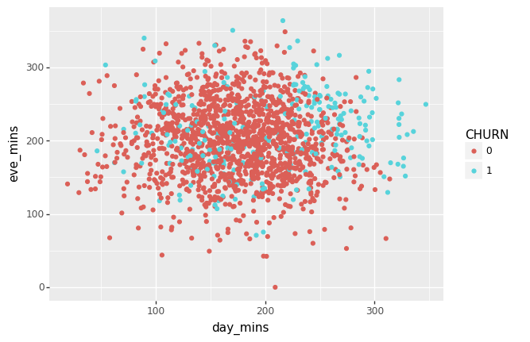

```python
#Sample data and plot
ex=out[['day_mins','eve_mins','CHURN']].to_frame(sample_pct=.5,stratify_by='CHURN')
ggplot(ex,aes(x='day_mins',y='eve_mins',color='CHURN')) + geom_point()
```

```python
out.state.value_counts().sort_values()
```

```
CA     34
IA     44
PA     45
LA     51
AK     52
TN     53
HI     53
GA     54
DC     54
AR     55
NH     56
IL     58
KY     59
SC     60
SD     60
DE     61
NE     61
OK     61
NM     62
ME     62
ND     62
FL     63
MO     63
AZ     64
MA     65
MS     65
RI     65
WA     66
NV     66
CO     66
MT     68
NC     68
NJ     68
MD     70
KS     70
IN     71
TX     72
UT     72
VT     73
ID     73
MI     73
CT     74
WY     77
VA     77
OH     78
WI     78
OR     78
AL     80
NY     83
MN     84
WV    106
dtype: int64
```

```python
out.account_length.describe([i for i in np.arange(.1,1,.1)])
```

```
count   3333.00
mean     101.06
std       39.82
min        1.00
10%       50.00
20%       67.00
30%       80.00
40%       91.00
50%      101.00
60%      111.00
70%      122.00
80%      134.00
90%      152.00
max      243.00
Name: account_length, dtype: float64
```

```python
out.binning(vars=["account_length"],
             copyAllVars=True,
             casout = dict(name=out,
                           replace=True)
            )
```

**§ VarTransInfo**

Variable Binning Information for CHURN

|  | Variable | ResultVar | NBins |
| --- | --- | --- | --- |
| 0 | account_length | BIN_account_length | 5.00 |

**§ BinDetails**

Bin Details for CHURN

|  | Variable | BinId | BinLowerBnd | BinUpperBnd | BinWidth | NInBin | Mean | Std | Min | Max |
| --- | --- | --- | --- | --- | --- | --- | --- | --- | --- | --- |
| 0 | account_length | 1 | 1.00 | 49.40 | 48.40 | 326 | 31.69 | 13.07 | 1.00 | 49.00 |
| 1 | account_length | 2 | 49.40 | 97.80 | 48.40 | 1233 | 76.57 | 13.31 | 50.00 | 97.00 |
| 2 | account_length | 3 | 97.80 | 146.20 | 48.40 | 1342 | 119.18 | 13.45 | 98.00 | 146.00 |
| 3 | account_length | 4 | 146.20 | 194.60 | 48.40 | 397 | 163.36 | 12.82 | 147.00 | 194.00 |
| 4 | account_length | 5 | 194.60 | 243.00 | 48.40 | 35 | 209.06 | 11.68 | 195.00 | 243.00 |

**§ OutputCasTables**

|  | casLib | Name | Rows | Columns | casTable |
| --- | --- | --- | --- | --- | --- |
| 0 | CASUSER(sasdemo) | CHURN | 3333 | 22 | CASTable('CHURN', caslib='CASUSER(sasdemo)') |

elapsed 0.0147s · user 0.0132s · sys 0.013s · mem 19.3MB

```python
out.cattrans(inputs=['state'],
             method='LABEL',
             copyAllVars=True,
             casout = dict(name=out,
                           replace=True))
```

**§ VarTransInfo**

Nominal Transformation Information for CHURN

|  | Variable | ResultVar |
| --- | --- | --- |
| 0 | state | CAT_state |

**§ BinDetails**

Bin Details for CHURN

|  | Variable | BinId | NInBin |
| --- | --- | --- | --- |

**§ OutputCasTables**

|  | casLib | Name | Rows | Columns | casTable |
| --- | --- | --- | --- | --- | --- |
| 0 | CASUSER(sasdemo) | CHURN | 3333 | 23 | CASTable('CHURN', caslib='CASUSER(sasdemo)') |

elapsed 0.0185s · user 0.0184s · sys 0.0126s · mem 19.4MB

```python
out.head()
```

Selected Rows from Table CHURN

|  | account_length | vmail_message | day_mins | eve_mins | night_mins | intl_mins | custserv_calls | day_calls | day_charge | eve_calls | ... | intl_calls | intl_charge | state | phone | INTL_PLAN | VMAIL_PLAN | AREA_CODE | CHURN | BIN_account_length | CAT_state |
| --- | --- | --- | --- | --- | --- | --- | --- | --- | --- | --- | --- | --- | --- | --- | --- | --- | --- | --- | --- | --- | --- |
| 0 | 128.00 | 25.00 | 265.10 | 197.40 | 244.70 | 10.00 | 1.00 | 110.00 | 45.07 | 99.00 | ... | 3.00 | 2.70 | KS | 382-4657 | 0 | 1 | 415 | 0 | 3.00 | 17.00 |
| 1 | 107.00 | 26.00 | 161.60 | 195.50 | 254.40 | 13.70 | 1.00 | 123.00 | 27.47 | 103.00 | ... | 3.00 | 3.70 | OH | 371-7191 | 0 | 1 | 415 | 0 | 3.00 | 36.00 |
| 2 | 137.00 | 0.00 | 243.40 | 121.20 | 162.60 | 12.20 | 0.00 | 114.00 | 41.38 | 110.00 | ... | 5.00 | 3.29 | NJ | 358-1921 | 0 | 0 | 415 | 0 | 3.00 | 32.00 |
| 3 | 84.00 | 0.00 | 299.40 | 61.90 | 196.90 | 6.60 | 2.00 | 71.00 | 50.90 | 88.00 | ... | 7.00 | 1.78 | OH | 375-9999 | 1 | 0 | 408 | 0 | 2.00 | 36.00 |
| 4 | 75.00 | 0.00 | 166.70 | 148.30 | 186.90 | 10.10 | 3.00 | 113.00 | 28.34 | 122.00 | ... | 3.00 | 2.73 | OK | 330-6626 | 1 | 0 | 415 | 0 | 2.00 | 37.00 |

5 rows × 23 columns

```python
out.altertable(columns=[dict(drop=True, name='BIN_account_length')])
out.altertable(columns=[dict(drop=True, name='CAT_state')])
```

elapsed 0.000812s · user 0.000774s · mem 0.291MB

Ok, we've seen some data manipulations, visualizations, lets do some **machine learning!**

```python
#As usual, load the action sets
conn.loadactionset(actionset="sampling")
conn.loadactionset(actionset="regression")
conn.loadactionset(actionset="autotune")
conn.loadactionset(actionset="decisionTree")
```

```
NOTE: Added action set 'sampling'.
NOTE: Added action set 'regression'.
NOTE: Added action set 'autotune'.
NOTE: Added action set 'decisionTree'.
```

**§ actionset**

decisionTree

elapsed 0.00306s · user 0.00212s · sys 0.000822s · mem 0.242MB

Apply a sampling scheme - we'll use stratified sampling and also return partition indicators

```python
#Conduct Sampling and see the data set
out_smpl=conn.sampling.stratified(
  table={"name":"CHURN", "groupby":'churn'},
  output={"casout":{"name":"churn_part", "replace":True}, "copyvars":"ALL"},
  samppct=70,
  partind=True
)
render_html(conn.CASTable('churn_part').head())
```

```
NOTE: Using SEED=1108268028 for sampling.
```

| Selected Rows from Table CHURN_PART |  |  |  |  |  |  |  |  |  |  |  |  |  |  |  |  |  |  |  |  |  |
| --- | --- | --- | --- | --- | --- | --- | --- | --- | --- | --- | --- | --- | --- | --- | --- | --- | --- | --- | --- | --- | --- |
| 128 | 25 | 265.1 | 197.4 | 244.7 | 10 | 1 | 110 | 45.07 | 99 | 16.78 | 91 | 11.01 | 3 | 2.7 | KS | 382-4657 | 0 | 1 | 415 | 0 | 0 |
| 107 | 26 | 161.6 | 195.5 | 254.4 | 13.7 | 1 | 123 | 27.47 | 103 | 16.62 | 103 | 11.45 | 3 | 3.7 | OH | 371-7191 | 0 | 1 | 415 | 0 | 1 |
| 137 | 0 | 243.4 | 121.2 | 162.6 | 12.2 | 0 | 114 | 41.38 | 110 | 10.3 | 104 | 7.32 | 5 | 3.29 | NJ | 358-1921 | 0 | 0 | 415 | 0 | 1 |
| 84 | 0 | 299.4 | 61.9 | 196.9 | 6.6 | 2 | 71 | 50.9 | 88 | 5.26 | 89 | 8.86 | 7 | 1.78 | OH | 375-9999 | 1 | 0 | 408 | 0 | 1 |
| 75 | 0 | 166.7 | 148.3 | 186.9 | 10.1 | 3 | 113 | 28.34 | 122 | 12.61 | 121 | 8.41 | 3 | 2.73 | OK | 330-6626 | 1 | 0 | 415 | 0 | 1 |

Next let's characterize our variables. Put them into sets or lists (basically sequence types that we can pass as arguments to the ML action calls later). Once again - you can get fancy with an expression or call out the variables

```python
#intialize var sets
noms=['area_code','churn','intl_plan','vmail_plan']
int_vars=['account_length', 'custserv_calls', 'day_calls', 'day_charge', 'day_mins', 'eve_calls',
          'eve_charge', 'eve_mins', 'intl_calls', 'intl_charge', 'intl_mins',
          'night_calls','night_charge', 'night_mins', 'vmail_message', ]
effect_vars=['area_code','account_length', 'custserv_calls', 'day_calls', 'day_charge',
             'day_mins', 'eve_calls','eve_charge', 'eve_mins', 'intl_calls',
             'intl_charge', 'intl_mins', 'intl_plan','night_calls','night_charge',
             'night_mins', 'vmail_message', 'vmail_plan']
#you can also easily set these variables up using expression like so -
#int_vars={i for i in cpart.dtypes[cpart.dtypes=='double'].index if i!='_PartInd_'}
```

```python
cpart = conn.CASTable('CHURN_PART') #reference the partitioned CAS Table
#Run Logistic Regression-- Please note that many of those keyword arguments passed are optional
#Its used here just to demonstrate flexibility
log_reg = cpart.logistic(class_=[dict(vars=noms)],
                                   model={"depvars":[{"name":"churn", "options":{"event":"1"}}],
                                        "effects":[dict(vars=effect_vars)]
                                         },
                                   partbyvar={"name": "_partind_", "train": "1", "valid": "0"},
                                   selection=dict(method="stepwise"),
                                   output=dict(casout=dict(name="scored_logistic_data",
                                                          replace=True),
                                              copyvars="ALL")
                                  )

render_html(log_reg)
#if a particular portion of the result is needed something like this can be done as well
#log_reg['SelectedModel.ParameterEstimates']
```

```
NOTE: Convergence criterion (GCONV=1E-8) satisfied.
```

| Model Information |  |  |
| --- | --- | --- |
| DATA | Data Source | CHURN_PART |
| RESPONSEVAR | Response Variable | CHURN |
| DIST | Distribution | Binary |
| LINK | Link Function | Logit |
| TECH | Optimization Technique | Newton-Raphson with Ridging |

| Number of Observations |  |  |  |  |
| --- | --- | --- | --- | --- |
| NREAD | Number of Observations Read | 3333 | 2333 | 1000 |
| NUSED | Number of Observations Used | 3333 | 2333 | 1000 |

| Response Profile |  |  |  |  |  |  |
| --- | --- | --- | --- | --- | --- | --- |
| 1 | 0 | 0 | 2850 | 1995 | 855 |  |
| 2 | 1 | 1 | 483 | 338 | 145 | * |

| Class Level Information |  |  |
| --- | --- | --- |
| AREA_CODE | 3 | 408 415 510 |
| INTL_PLAN | 2 | 0 1 |
| VMAIL_PLAN | 2 | 0 1 |

| Selection Information |  |  |  |
| --- | --- | --- | --- |
| METHOD | Selection Method | Stepwise | nan |
| SELCRITERION | Select Criterion | SBC | nan |
| STOPCRITERION | Stop Criterion | SBC | nan |
| HIERARCHY | Effect Hierarchy Enforced | None | nan |
| STOPHORIZON | Stop Horizon | 3 | 3 |

| Convergence Status |  |  |
| --- | --- | --- |
| Convergence criterion (GCONV=1E-8) satisfied. | 0 | 4.6337036E-9 |

[output not shown]

| Stop Reason |  |
| --- | --- |
| Stepwise selection stopped because adding or removing an effect does not improve the SBC criterion. | 8 |

| Selection Reason |
| --- |
| The model at step 8 is selected. |

| Selected Effects |  |
| --- | --- |
| Selected Effects: | Intercept custserv_calls day_mins eve_charge intl_calls intl_charge INTL_PLAN night_charge VMAIL_PLAN |

| Dimensions |  |  |
| --- | --- | --- |
| NDESIGNCOLS | Columns in Design | 11 |
| NEFFECTS | Number of Effects | 9 |
| MAXEFCOLS | Max Effect Columns | 2 |
| DESIGNRANK | Rank of Design | 9 |
| OPTPARM | Parameters in Optimization | 9 |

| Likelihood Ratio Test |  |  |  |
| --- | --- | --- | --- |
| Likelihood Ratio | 8 | 436.20408352 | 3.336584E-89 |

| Fit Statistics |  |  |  |
| --- | --- | --- | --- |
| M2LL | -2 Log Likelihood | 1494.2148964 | 678.47032905 |
| AIC | AIC (smaller is better) | 1512.2148964 | 696.47032905 |
| AICC | AICC (smaller is better) | 1512.2923824 | 696.65214723 |
| SBC | SBC (smaller is better) | 1564.0090888 | 740.64012656 |
| ASE | Average Square Error | 0.096580067 | 0.1027998717 |
| M2LLNULL | -2 Log L (Intercept-only) | 1930.4189799 | 827.87426078 |
| RSQUARE | R-Square | 0.1705324727 | 0.1387788299 |
| ADJRSQ | Max-rescaled R-Square | 0.3029893247 | 0.2464888274 |
| MCFADDEN | McFadden's R-Square | 0.2259634246 | 0.1804669366 |
| MISCLASS | Misclassification Rate | 0.1307329619 | 0.148 |
| DIFFMEAN | Difference of Means | 0.2207341365 | 0.1994313093 |

| Parameter Estimates |  |  |  |  |  |  |  |  |  |
| --- | --- | --- | --- | --- | --- | --- | --- | --- | --- |
| Intercept |  |  | Intercept | Intercept | 1 | -7.472387597 | 0.6438130345 | 134.70981873 | 3.821279E-31 |
| custserv_calls |  |  | custserv_calls | custserv_calls | 1 | 0.5133979081 | 0.0489237091 | 110.12082049 | 9.219661E-26 |
| day_mins |  |  | day_mins | day_mins | 1 | 0.0151551066 | 0.0013123949 | 133.34873287 | 7.584698E-31 |
| eve_charge |  |  | eve_charge | eve_charge | 1 | 0.0949579641 | 0.0162302461 | 34.230447611 | 4.8956955E-9 |
| intl_calls |  |  | intl_calls | intl_calls | 1 | -0.11306926 | 0.0304825144 | 13.759020572 | 0.0002078204 |
| intl_charge |  |  | intl_charge | intl_charge | 1 | 0.2888185522 | 0.0902459182 | 10.242242112 | 0.0013726065 |
| INTL_PLAN | 0 |  | INTL_PLAN 0 | INTL_PLAN_0 | 1 | -1.997792956 | 0.1756185651 | 129.40769644 | 5.522583E-30 |
| INTL_PLAN | 1 |  | INTL_PLAN 1 | INTL_PLAN_1 | 0 | 0 | nan | nan | nan |
| night_charge |  |  | night_charge | night_charge | 1 | 0.0996284081 | 0.0295952331 | 11.332424949 | 0.0007616538 |
| VMAIL_PLAN |  | 0 | VMAIL_PLAN 0 | VMAIL_PLAN_0 | 1 | 0.8147219767 | 0.1716725181 | 22.522536929 | 2.0769257E-6 |
| VMAIL_PLAN |  | 1 | VMAIL_PLAN 1 | VMAIL_PLAN_1 | 0 | 0 | nan | nan | nan |

| Task Timing |  |  |  |
| --- | --- | --- | --- |
| SETUP | Setup and Parsing | 0.0045609474 | 0.0176850108 |
| LEVELIZATION | Levelization | 0.0054969788 | 0.0213144595 |
| INITIALIZATION | Model Initialization | 0.000838995 | 0.0032531915 |
| SSCP | SSCP Computation | 0.0029451847 | 0.0114199132 |
| FITTING | Model Selection | 0.2328739166 | 0.9029654056 |
| OUTPUT | Creating Output Data | 0.0107848644 | 0.0418181633 |
| CLEANUP | Cleanup | 0.0001339912 | 0.0005195492 |
| TOTAL | Total | 0.2578990459 | 1 |

| Output CAS Tables |  |  |  |  |  |
| --- | --- | --- | --- | --- | --- |
| CASUSER(sasdemo) | scored_logistic_data |  | 3333 | 23 | CASTable('scored_logistic_data', caslib='CASUSER(sasdemo)') |

Obviously,you can also **run SAS data step** code to create new variables!

```python
# Compute _pred0_ variable (1-_pred_)
conn.dataStep.runCode(
  code="data scored_logistic_data; set scored_logistic_data; _pred0_=1-_pred_; run;"
)
```

**§ InputCasTables**

|  | casLib | Name | Rows | Columns | casTable |
| --- | --- | --- | --- | --- | --- |
| 0 | CASUSER(sasdemo) | scored_logistic_data | 3333 | 23 | CASTable('scored_logistic_data', caslib='CASUS... |

**§ OutputCasTables**

|  | casLib | Name | Rows | Columns | Append | casTable |
| --- | --- | --- | --- | --- | --- | --- |
| 0 | CASUSER(sasdemo) | scored_logistic_data | 3333 | 24 | nan | CASTable('scored_logistic_data', caslib='CASUS... |

elapsed 0.064s · user 0.0133s · sys 0.0729s · mem 4.92MB

Next, **Random Forest Model**

```python
#Model Training -
##1.Train the model on the training data
##2.Get important variables
##3. Write the model definition into a table
r_forest=cpart[cpart['_PartInd_']==1].decisiontree.foresttrain(
                                                               nominals=noms,
                                                               inputs=effect_vars,
                                                               target="churn",
                                                               varimp=True,
                                                               event='1',
                                                              casout=dict(name="rf_model", caslib="casuser",
                                                              replace=True),
                                                              savestate=dict(name='forest_model_train',
                                                                             replace=True))

r_forest #look at the results
```

```
NOTE: Wrote 792364 bytes to the savestate file forest_model_train.
```

**§ ModelInfo**

Forest for CHURN_PART

|  | Descr | Value |
| --- | --- | --- |
| 0 | Number of Trees | 50.00 |
| 1 | Number of Selected Variables (M) | 5.00 |
| 2 | Random Number Seed | 0.00 |
| 3 | Bootstrap Percentage (%) | 63.21 |
| 4 | Number of Bins | 20.00 |
| 5 | Number of Variables | 18.00 |
| 6 | Confidence Level for Pruning | 0.25 |
| 7 | Max Number of Tree Nodes | 31.00 |
| 8 | Min Number of Tree Nodes | 13.00 |
| 9 | Max Number of Branches | 2.00 |
| 10 | Min Number of Branches | 2.00 |
| 11 | Max Number of Levels | 6.00 |
| 12 | Min Number of Levels | 6.00 |
| 13 | Max Number of Leaves | 16.00 |
| 14 | Min Number of Leaves | 7.00 |
| 15 | Maximum Size of Leaves | 1428.00 |
| 16 | Minimum Size of Leaves | 5.00 |
| 17 | Out-of-Bag MCR (%) | nan |

**§ DTreeVarImpInfo**

Forest for CHURN_PART

|  | Variable | Importance | Std |
| --- | --- | --- | --- |
| 0 | day_charge | 33.13 | 13.88 |
| 1 | custserv_calls | 18.53 | 10.10 |
| 2 | day_mins | 15.72 | 11.95 |
| 3 | INTL_PLAN | 12.66 | 10.39 |
| 4 | intl_charge | 5.50 | 9.99 |
| 5 | intl_calls | 5.36 | 10.39 |
| 6 | intl_mins | 3.68 | 8.64 |
| 7 | vmail_message | 3.38 | 5.43 |
| 8 | eve_charge | 2.68 | 4.15 |
| 9 | eve_mins | 2.59 | 4.51 |
| 10 | VMAIL_PLAN | 1.53 | 7.08 |
| 11 | day_calls | 0.85 | 1.79 |
| 12 | night_charge | 0.71 | 1.26 |
| 13 | night_mins | 0.54 | 1.57 |
| 14 | eve_calls | 0.42 | 1.14 |
| 15 | account_length | 0.33 | 0.62 |
| 16 | night_calls | 0.26 | 1.14 |
| 17 | AREA_CODE | 0.13 | 1.03 |

**§ OutputCasTables**

|  | casLib | Name | Rows | Columns | casTable |
| --- | --- | --- | --- | --- | --- |
| 0 | CASUSER(sasdemo) | rf_model | 1040 | 28 | CASTable('rf_model', caslib='CASUSER(sasdemo)') |

elapsed 0.453s · user 0.704s · sys 0.253s · mem 16.1MB

Model scoring is simple!

```python
#Model Scoring
cpart.forestscore(modeltable='rf_model',
                 casout=dict(name="scored_rf_data",
                             replace=True, caslib='casuser'),
                 copyVars={"churn","_partind_"},
                  vote="PROB")
```

**§ OutputCasTables**

|  | casLib | Name | Rows | Columns | casTable |
| --- | --- | --- | --- | --- | --- |
| 0 | CASUSER(sasdemo) | scored_rf_data | 3333 | 7 | CASTable('scored_rf_data', caslib='CASUSER(sas... |

**§ ScoreInfo**

|  | Descr | Value |
| --- | --- | --- |
| 0 | Number of Observations Read | 3333 |
| 1 | Number of Observations Used | 3333 |
| 2 | Misclassification Error (%) | 11.131113111 |

elapsed 0.0397s · user 0.0537s · sys 0.0144s · mem 18.3MB

```python
conn.fedsql.execdirect("""create table casuser.scored_rf_data {options replace=true} as
                       (select *,
                       case when _rf_predname_=1 then _rf_predp_ else 1-_rf_predp_ end as _pred_,
                       case when _rf_predname_=0 then _rf_predp_ else 1-_rf_predp_ end as _pred0_
                       from scored_rf_data
                       )
                       """)

#sneak peek at the data
dat=conn.CASTable('scored_rf_data')
dat[dat['_RF_PredName_']>0].head() #show me some churn events
```

```
NOTE: Table SCORED_RF_DATA was created in caslib CASUSER(sasdemo) with 3333 rows returned.
```

Selected Rows from Table SCORED_RF_DATA

|  | _PartInd_ | CHURN | _RF_PredName_ | _RF_PredP_ | _RF_PredLevel_ | _MissIt_ | _Vote_ | _PRED_ | _PRED0_ |
| --- | --- | --- | --- | --- | --- | --- | --- | --- | --- |
| 0 | 1.00 | 1 | 1 | 0.95 | 1.00 | 0.00 | 47.42 | 0.95 | 0.05 |
| 1 | 1.00 | 1 | 1 | 0.56 | 1.00 | 0.00 | 28.24 | 0.56 | 0.44 |
| 2 | 1.00 | 1 | 1 | 0.56 | 1.00 | 0.00 | 28.16 | 0.56 | 0.44 |
| 3 | 1.00 | 1 | 1 | 0.61 | 1.00 | 0.00 | 30.28 | 0.61 | 0.39 |
| 4 | 0.00 | 1 | 1 | 1.00 | 1.00 | 0.00 | 50.00 | 1.00 | 0.00 |

**Now, Let's try some auto tuning**

```python
from rpart_tuner import recursive_partitioning_tuner
tree_factory = ['auto_tree','auto_forest','auto_gradboost']
## We care about this section the most ##
tuning_results = recursive_partitioning_tuner(conn=conn, input_table = cpart,
                                              inputs = effect_vars,
                                              nominals = noms,
                                              target = "churn",
                                              autotune_factory = tree_factory)
```

```
NOTE: Autotune is started for 'Decision Tree' model.
NOTE: Autotune option SEARCHMETHOD='GA'.
NOTE: Autotune option MAXTIME=36000 (sec.).
NOTE: Autotune option SEED=54321.
NOTE: Autotune objective is 'Misclassification Error Percentage'.
NOTE: Autotune number of parallel evaluations is set to 4, each using 0 worker nodes.
         Iteration       Evals     Best Objective  Elapsed Time
                 0           1                6.7          0.16
                 1          17                  6          3.53
                 2          30                  6          4.45
                 3          43                  6          5.87
                 4          52                  6          6.31
                 5          59                5.3          6.81
NOTE: Data was partitioned during tuning, to tune based on validation score; the final model is trained and scored on all data.
NOTE: Autotune time is 7.05 seconds.
NOTE: Autotune is started for 'Forest' model.
NOTE: Autotune option SEARCHMETHOD='GA'.
NOTE: Autotune option MAXTIME=36000 (sec.).
NOTE: Autotune option SEED=54321.
NOTE: Autotune objective is 'Misclassification Error Percentage'.
NOTE: Autotune number of parallel evaluations is set to 4, each using 0 worker nodes.
         Iteration       Evals     Best Objective  Elapsed Time
                 0           1                5.9          1.60
                 1          19                5.8          7.49
                 2          29                5.6         11.84
                 3          46                5.6         21.06
                 4          62                5.5         31.68
                 5          77                5.5         41.09
NOTE: Data was partitioned during tuning, to tune based on validation score; the final model is trained and scored on all data.
NOTE: Wrote 2433908 bytes to the savestate file auto_forest_save.
NOTE: Autotune time is 41.68 seconds.
NOTE: Autotune is started for 'Gradient Boosting Tree' model.
NOTE: Autotune option SEARCHMETHOD='GA'.
NOTE: Autotune option MAXTIME=36000 (sec.).
NOTE: Autotune option SEED=54321.
NOTE: Autotune objective is 'Misclassification Error Percentage'.
NOTE: Early stopping is activated; 'NTREE' will not be tuned.
NOTE: Autotune number of parallel evaluations is set to 4, each using 0 worker nodes.
NOTE: Automatic early stopping is activated with STAGNATION=4;  set EARLYSTOP=false to deactivate.
         Iteration       Evals     Best Objective  Elapsed Time
                 0           1               14.5          0.37
                 1          25                5.8         20.26
                 2          46                5.5         39.08
                 3          65                5.2         61.74
                 4          88                4.7         77.43
                 5         110                4.6         94.29
NOTE: Data was partitioned during tuning, to tune based on validation score; the final model is trained and scored on all data.
NOTE: Wrote 1591764 bytes to the savestate file auto_gradboost_save.
NOTE: Autotune time is 96.56 seconds.
```

Explore the results of the auto-tuning process by model type

```python
total_evaluations_by_CAS_AutoTuner = 0
for i in tuning_results.keys():
    tuned_configurations = tuning_results[i]["TunerSummary"][tuning_results[i]
            ["TunerSummary"]["Parameter"]=="Number of Evaluated Configurations"]["Value"]
    total_evaluations_by_CAS_AutoTuner += tuned_configurations
print(f"""A total of {int(total_evaluations_by_CAS_AutoTuner)} tuning configurations were tested by CAS across models""")
```

```
A total of 246 tuning configurations were tested by CAS across models
```

```python
tuning_results["gradboost"]
```

**§ ModelInfo**

Gradient Boosting Tree for CHURN_PART_AUTOTUNE_07OCT2019:19:03:08

|  | Descr | Value |
| --- | --- | --- |
| 0 | Number of Trees | 150.00 |
| 1 | Distribution | 2.00 |
| 2 | Learning Rate | 0.50 |
| 3 | Subsampling Rate | 0.75 |
| 4 | Number of Selected Variables (M) | 17.00 |
| 5 | Number of Bins | 69.00 |
| 6 | Number of Variables | 18.00 |
| 7 | Max Number of Tree Nodes | 53.00 |
| 8 | Min Number of Tree Nodes | 13.00 |
| 9 | Max Number of Branches | 2.00 |
| 10 | Min Number of Branches | 2.00 |
| 11 | Max Number of Levels | 7.00 |
| 12 | Min Number of Levels | 7.00 |
| 13 | Max Number of Leaves | 27.00 |
| 14 | Min Number of Leaves | 7.00 |
| 15 | Maximum Size of Leaves | 1681.00 |
| 16 | Minimum Size of Leaves | 5.00 |
| 17 | Random Number Seed | 54321.00 |

**§ DTreeVarImpInfo**

Decision Tree for CHURN_PART_AUTOTUNE_07OCT2019:19:03:08

|  | Variable | Importance | Std |
| --- | --- | --- | --- |
| 0 | day_charge | 3.45 | 8.39 |
| 1 | custserv_calls | 2.16 | 11.01 |
| 2 | INTL_PLAN | 1.63 | 9.89 |
| 3 | eve_charge | 1.53 | 2.93 |
| 4 | VMAIL_PLAN | 0.97 | 6.71 |
| 5 | intl_charge | 0.81 | 1.89 |
| 6 | intl_calls | 0.56 | 2.34 |
| 7 | night_charge | 0.42 | 0.42 |
| 8 | account_length | 0.31 | 0.26 |
| 9 | day_calls | 0.29 | 0.21 |
| 10 | eve_calls | 0.27 | 0.22 |
| 11 | night_calls | 0.26 | 0.19 |
| 12 | day_mins | 0.16 | 2.55 |
| 13 | vmail_message | 0.12 | 0.23 |
| 14 | night_mins | 0.07 | 0.35 |
| 15 | AREA_CODE | 0.03 | 0.15 |
| 16 | eve_mins | 0.03 | 0.29 |
| 17 | intl_mins | 0.01 | 0.08 |

**§ EvalMetricInfo**

|  | Progress | Metric |
| --- | --- | --- |
| 0 | 1.00 | 0.14 |
| 1 | 2.00 | 0.07 |
| 2 | 3.00 | 0.06 |
| 3 | 4.00 | 0.05 |
| 4 | 5.00 | 0.05 |
| ... | ... | ... |
| 61 | 62.00 | 0.02 |
| 62 | 63.00 | 0.02 |
| 63 | 64.00 | 0.02 |
| 64 | 65.00 | 0.02 |
| 65 | 66.00 | 0.02 |

66 rows × 2 columns

**§ ScoreInfo**

|  | Descr | Value |
| --- | --- | --- |
| 0 | Number of Observations Read | 3333 |
| 1 | Number of Observations Used | 3333 |
| 2 | Misclassification Error (%) | 2.0102010201 |

**§ ErrorMetricInfo**

|  | TreeID | Trees | NLeaves | MCR | LogLoss | ASE | RASE | MAXAE |
| --- | --- | --- | --- | --- | --- | --- | --- | --- |
| 0 | 0.00 | 1.00 | 20.00 | 0.14 | 0.28 | 0.08 | 0.28 | 0.90 |
| 1 | 1.00 | 2.00 | 44.00 | 0.07 | 0.23 | 0.06 | 0.25 | 0.93 |
| 2 | 2.00 | 3.00 | 70.00 | 0.06 | 0.20 | 0.05 | 0.23 | 0.95 |
| 3 | 3.00 | 4.00 | 94.00 | 0.05 | 0.19 | 0.05 | 0.22 | 0.96 |
| 4 | 4.00 | 5.00 | 117.00 | 0.05 | 0.18 | 0.04 | 0.21 | 0.97 |
| ... | ... | ... | ... | ... | ... | ... | ... | ... |
| 61 | 61.00 | 62.00 | 1091.00 | 0.02 | 0.09 | 0.02 | 0.14 | 1.00 |
| 62 | 62.00 | 63.00 | 1107.00 | 0.02 | 0.09 | 0.02 | 0.14 | 1.00 |
| 63 | 63.00 | 64.00 | 1119.00 | 0.02 | 0.08 | 0.02 | 0.14 | 1.00 |
| 64 | 64.00 | 65.00 | 1131.00 | 0.02 | 0.08 | 0.02 | 0.14 | 1.00 |
| 65 | 65.00 | 66.00 | 1143.00 | 0.02 | 0.08 | 0.02 | 0.14 | 1.00 |

66 rows × 8 columns

**§ TunerInfo**

Tuner Information

|  | Parameter | Value |
| --- | --- | --- |
| 0 | Model Type | Gradient Boosting Tree |
| 1 | Tuner Objective Function | Misclassification Error Percentage |
| 2 | Search Method | GA |
| 3 | Population Size | 10 |
| 4 | Maximum Iterations | 5 |
| 5 | Maximum Tuning Time in Seconds | 36000 |
| 6 | Validation Type | Single Partition |
| 7 | Validation Partition Fraction | 0.30 |
| 8 | Log Level | 2 |
| 9 | Seed | 54321 |
| 10 | Number of Parallel Evaluations | 4 |
| 11 | Number of Workers per Subsession | 0 |

**§ TunerResults**

Tuner Results

|  | Evaluation | M | LEARNINGRATE | SUBSAMPLERATE | LASSO | RIDGE | NBINS | MAXLEVEL | MisclassErr | EvaluationTime |
| --- | --- | --- | --- | --- | --- | --- | --- | --- | --- | --- |
| 0 | 0 | 18 | 0.10 | 0.50 | 0.00 | 1.00 | 50 | 5 | 14.50 | 0.37 |
| 1 | 100 | 17 | 0.50 | 0.75 | 5.00 | 5.51 | 69 | 7 | 4.60 | 3.82 |
| 2 | 106 | 17 | 0.50 | 0.75 | 0.00 | 5.51 | 69 | 4 | 4.60 | 2.75 |
| 3 | 79 | 17 | 0.50 | 0.75 | 0.00 | 5.51 | 29 | 4 | 4.70 | 2.94 |
| 4 | 83 | 17 | 0.50 | 0.75 | 5.00 | 5.51 | 69 | 4 | 4.70 | 2.93 |
| 5 | 99 | 17 | 0.50 | 0.75 | 5.00 | 0.51 | 69 | 4 | 4.70 | 2.32 |
| 6 | 110 | 17 | 0.50 | 1.00 | 5.00 | 5.51 | 69 | 4 | 4.70 | 0.67 |
| 7 | 72 | 16 | 0.55 | 0.75 | 4.30 | 6.13 | 26 | 5 | 4.90 | 1.24 |
| 8 | 80 | 17 | 0.50 | 1.00 | 5.00 | 5.51 | 29 | 4 | 5.00 | 1.42 |
| 9 | 82 | 17 | 0.50 | 0.75 | 5.00 | 0.51 | 29 | 4 | 5.00 | 2.04 |
| 10 | 93 | 16 | 0.55 | 0.75 | 4.27 | 6.13 | 27 | 5 | 5.00 | 3.51 |

**§ IterationHistory**

Tuner Iteration History

|  | Iteration | Evaluations | Best_obj | Time_sec |
| --- | --- | --- | --- | --- |
| 0 | 0 | 1 | 14.50 | 0.37 |
| 1 | 1 | 25 | 5.80 | 20.63 |
| 2 | 2 | 46 | 5.50 | 39.44 |
| 3 | 3 | 65 | 5.20 | 62.11 |
| 4 | 4 | 88 | 4.70 | 77.80 |
| 5 | 5 | 110 | 4.60 | 94.66 |

**§ EvaluationHistory**

Tuner Evaluation History

|  | Evaluation | Iteration | M | LEARNINGRATE | SUBSAMPLERATE | LASSO | RIDGE | NBINS | MAXLEVEL | MisclassErr | EvaluationTime |
| --- | --- | --- | --- | --- | --- | --- | --- | --- | --- | --- | --- |
| 0 | 0 | 0 | 18 | 0.10 | 0.50 | 0.00 | 1.00 | 50 | 5 | 14.50 | 0.37 |
| 1 | 1 | 1 | 7 | 1.00 | 0.60 | 4.44 | 7.78 | 56 | 4 | 7.60 | 7.28 |
| 2 | 2 | 1 | 9 | 0.45 | 0.20 | 10.00 | 6.67 | 82 | 7 | 14.50 | 1.49 |
| 3 | 3 | 1 | 16 | 0.34 | 1.00 | 8.89 | 2.22 | 20 | 3 | 6.80 | 3.11 |
| 4 | 4 | 1 | 12 | 0.78 | 0.40 | 0.00 | 4.44 | 47 | 5 | 7.80 | 4.17 |
| ... | ... | ... | ... | ... | ... | ... | ... | ... | ... | ... | ... |
| 106 | 106 | 5 | 17 | 0.50 | 0.75 | 0.00 | 5.51 | 69 | 4 | 4.60 | 2.75 |
| 107 | 107 | 5 | 9 | 0.50 | 0.75 | 5.00 | 5.51 | 69 | 4 | 5.80 | 2.30 |
| 108 | 108 | 5 | 17 | 1.00 | 0.75 | 5.00 | 5.51 | 69 | 4 | 5.90 | 1.43 |
| 109 | 109 | 5 | 17 | 0.01 | 0.75 | 5.00 | 5.51 | 69 | 4 | 14.50 | 0.45 |
| 110 | 110 | 5 | 17 | 0.50 | 1.00 | 5.00 | 5.51 | 69 | 4 | 4.70 | 0.67 |

111 rows × 11 columns

**§ BestConfiguration**

Best Configuration

|  | Parameter | Name | Value |
| --- | --- | --- | --- |
| 0 | Evaluation | Evaluation | 100 |
| 1 | Number of Variables to Try | M | 17 |
| 2 | Learning Rate | LEARNINGRATE | 0.50170757 |
| 3 | Sampling Rate | SUBSAMPLERATE | 0.75049391 |
| 4 | Lasso | LASSO | 5.00190043 |
| 5 | Ridge | RIDGE | 5.50791392 |
| 6 | Number of Bins | NBINS | 69 |
| 7 | Maximum Tree Levels | MAXLEVEL | 7 |
| 8 | Misclassification Error Percentage | Objective | 4.60 |

**§ TunerSummary**

Tuner Summary

|  | Parameter | Value |
| --- | --- | --- |
| 0 | Initial Configuration Objective Value | 14.50 |
| 1 | Best Configuration Objective Value | 4.60 |
| 2 | Worst Configuration Objective Value | 14.50 |
| 3 | Initial Configuration Evaluation Time in Seconds | 0.37 |
| 4 | Best Configuration Evaluation Time in Seconds | 3.82 |
| 5 | Number of Improved Configurations | 8.00 |
| 6 | Number of Evaluated Configurations | 110.00 |
| 7 | Total Tuning Time in Seconds | 96.56 |
| 8 | Parallel Tuning Speedup | 3.80 |

**§ TunerTiming**

Tuner Task Timing

|  | Task | Time_sec | Time_percent |
| --- | --- | --- | --- |
| 0 | Model Training | 357.85 | 97.55 |
| 1 | Model Scoring | 8.80 | 2.40 |
| 2 | Total Objective Evaluations | 366.66 | 99.95 |
| 3 | Tuner | 0.18 | 0.05 |
| 4 | Total CPU Time | 366.85 | 100.00 |

**§ TunerCasOutputTables**

Tuner CAS Output Tables

|  | CAS_Library | Name | Rows | Columns |
| --- | --- | --- | --- | --- |
| 0 | CASUSER(sasdemo) | auto_gradboost_model | 2220 | 24 |
| 1 | CASUSER(sasdemo) | auto_gradboost_save | 1 | 2 |

elapsed 96.6s · user 0.777s · sys 1.01s · mem 0.267MB

```python
from rpart_tuner import collect_scored_data
copy_vars = {"churn","_partind_"}
model_tables = [i  for i in conn.tableinfo()["TableInfo"]["Name"] if "auto" in i.lower() and "model" in i.lower()]
auto_score_results = collect_scored_data(conn,model_tables,cpart,copy_vars)
```

```
NOTE: Table AUTO_TREE_DATA was created in caslib CASUSER(sasdemo) with 3333 rows returned.
NOTE: Table AUTO_FOREST_DATA was created in caslib CASUSER(sasdemo) with 3333 rows returned.
NOTE: Table AUTO_GRADBOOST_DATA was created in caslib CASUSER(sasdemo) with 3333 rows returned.
```

```python
auto_score_results["FOREST"]
```

**§ OutputCasTables**

|  | casLib | Name | Rows | Columns | casTable |
| --- | --- | --- | --- | --- | --- |
| 0 | CASUSER(sasdemo) | AUTO_FOREST_DATA | 3333 | 7 | CASTable('AUTO_FOREST_DATA', caslib='CASUSER(s... |

**§ ScoreInfo**

|  | Descr | Value |
| --- | --- | --- |
| 0 | Number of Observations Read | 3333 |
| 1 | Number of Observations Used | 3333 |
| 2 | Misclassification Error (%) | 4.7404740474 |

elapsed 0.0652s · user 0.128s · mem 19.5MB

We'll use the tables above to assess the model on the validation data set. We'll do this for all the models we built

```python
#Simple Pandas Style Subsetting to create validation data references for both Log Reg and RF
#get a CASTable Ref
scored_data_log=conn.CASTable('scored_logistic_data')
scored_data_forest=conn.CASTable('scored_rf_data')
auto_forest_data = conn.CASTable("AUTO_FOREST_DATA")
auto_gradboost_data = conn.CASTable("AUTO_GRADBOOST_DATA")
auto_tree_data = conn.CASTable("AUTO_TREE_DATA")
#Easy subsetting
valid_data_logistic=scored_data_log[scored_data_log['_PartInd_']==0]  #subset for Log Reg
valid_data_rf =scored_data_forest[scored_data_forest['_PartInd_']==0] #subset for RF

#for AutoTuned Models
valid_data_auto_forest=auto_forest_data[auto_forest_data['_PartInd_']==0]
valid_data_auto_gradboost =auto_gradboost_data[auto_gradboost_data['_PartInd_']==0]
valid_data_auto_tree = auto_tree_data[auto_tree_data['_PartInd_']==0]
```

Helper function for model assessment - it generates and collects the validation metrics

```python
def assess_model(validation_dataset):
    """This funtion calls the assessment action with the appropriate settings
    on the dataset passed"""
    return validation_dataset.assess(
      inputs=[{"name":"_pred_"}],
      response="churn",
      event="1",
      pVar={"_pred0_"},
      pEvent={"0"}
    )
```

Only Pick Up metrics we care about

```python
#Pick up all assessmet Metrics
logistic_assess=assess_model(validation_dataset=valid_data_logistic)
logistic_fitstat =logistic_assess.FitStat
logistic_rocinfo =logistic_assess.ROCInfo
logistic_liftinfo=logistic_assess.LIFTInfo

rf_assess=assess_model(validation_dataset=valid_data_rf)
rf_fitstat =rf_assess.FitStat
rf_rocinfo =rf_assess.ROCInfo
rf_liftinfo=rf_assess.LIFTInfo

auto_forest_asses = assess_model(validation_dataset=valid_data_auto_forest)
auto_forest_fitstat = auto_forest_asses.FitStat
auto_forest_rocinfo = auto_forest_asses.ROCInfo
auto_forest_lift_info = auto_forest_asses.LIFTInfo

auto_gradboost_asses = assess_model(validation_dataset=valid_data_auto_gradboost)
auto_gradboost_fitstat = auto_gradboost_asses.FitStat
auto_gradboost_rocinfo = auto_gradboost_asses.ROCInfo
auto_gradboost_lift_info = auto_gradboost_asses.LIFTInfo

auto_tree_asses = assess_model(validation_dataset=valid_data_auto_tree)
auto_tree_fitstat = auto_tree_asses.FitStat
auto_tree_rocinfo = auto_tree_asses.ROCInfo
auto_tree_lift_info = auto_tree_asses.LIFTInfo
```

Some final simple data prep work for model assessment - also note,at this point eveything is happening on the client side

```python
# Add new variable to indicate type of model
logistic_liftinfo["model"]="Logistic Regression"
logistic_rocinfo["model"]="Logistic Regression"
rf_liftinfo["model"]="Forest"
rf_rocinfo["model"]="Forest"

auto_forest_lift_info["model"] = "Auto-Forest"
auto_forest_rocinfo["model"] = "Auto-Forest"

auto_tree_lift_info["model"] = "Auto-Tree"
auto_tree_rocinfo["model"] = "Auto-Tree"

auto_gradboost_lift_info["model"] = "Auto-GradBoost"
auto_gradboost_rocinfo["model"] = "Auto-Gradboost"


all_liftinfo = pd.concat([rf_liftinfo,logistic_liftinfo,auto_forest_lift_info,
                         auto_gradboost_lift_info, auto_tree_lift_info])


all_rocinfo = pd.concat([rf_rocinfo,logistic_rocinfo,auto_forest_rocinfo,
                         auto_gradboost_rocinfo, auto_tree_rocinfo])

all_rocinfo.to_csv("ml_exercise.csv",index=False)
# #Get lift and ROC info together
# all_liftinfo=rf_liftinfo.append(logistic_liftinfo, ignore_index=True)
# all_rocinfo=rf_rocinfo.append(logistic_rocinfo, ignore_index=True)
```

And, the metrics we care about AUC, the ROC Curve and the lift chart..

```python
print("AUC (using validation data)".center(80, '-'))
cas_models_summary = all_rocinfo[["model", "C"]].drop_duplicates(keep="first").sort_values(by="C", ascending=False)
cas_models_summary
```

```
--------------------------AUC (using validation data)---------------------------
```

|  | model | C |
| --- | --- | --- |
| 0 | Auto-Gradboost | 0.99 |
| 0 | Auto-Tree | 0.98 |
| 0 | Auto-Forest | 0.94 |
| 0 | Forest | 0.89 |
| 0 | Logistic Regression | 0.80 |

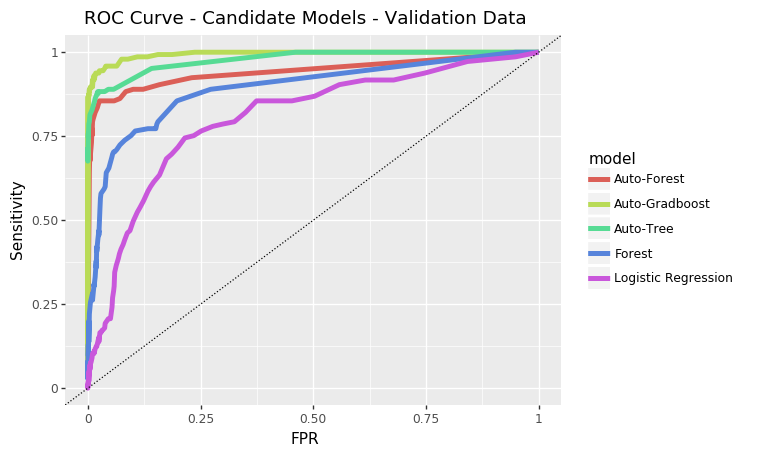

```python
#model_groups=all_rocinfo.groupby('model')
ggplot(all_rocinfo, aes(x='FPR', y='Sensitivity',color='model')) +\
    geom_line(linetype='solid',size=2) +\
    geom_abline(linetype='dotted') +\
    ggtitle('ROC Curve - Candidate Models - Validation Data') +\
    ylim(0,1) + xlim(0,1)
```

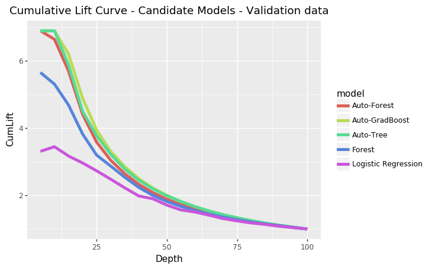

```python
ggplot(all_liftinfo, aes(x='Depth', y='CumLift',color='model')) +\
    geom_line(linetype='solid',size=2) +\
    ggtitle('Cumulative Lift Curve - Candidate Models - Validation data')
```

```
# Alternatively using Matplotlib
#/* Draw ROC charts */
plt.figure()
for key, grp in all_rocinfo.groupby(["model"]):
    plt.plot(grp["FPR"], grp["Sensitivity"], label=key)
plt.plot([0,1], [0,1], "k--")
plt.xlabel("False Positive Rate")
plt.ylabel("True Positive Rate")
plt.grid(True)
plt.legend(loc="best")
plt.title("ROC Curve (using validation data)")
plt.show()

#/* Draw lift charts */
plt.figure()
for key, grp in all_liftinfo.groupby(["model"]):
    plt.plot(grp["Depth"], grp["Lift"], label=key)
plt.xlabel("Depth")
plt.ylabel("Lift")
plt.grid(True)
plt.legend(loc="best")
plt.title("Lift Chart (using validation data)")
plt.show()
```

Promote any of the data sets to the global scope if needed..

```python
 #conn.setsessopt(caslib='public')
 #conn.droptable('churn')
 #conn.setsessopt(caslib='casuser')
```

```python
conn.table.promote(name='churn',drop=True, targetlib='public')
```

elapsed 0.00173s · sys 0.00116s · mem 0.272MB

```python
#create ASTOREs
conn.table.save(table='AUTO_FOREST_SAVE',
                name ='forest_model_champ.sashdat', caslib="Public", replace=True)
```

```
NOTE: Cloud Analytic Services saved the file forest_model_champ.sashdat in caslib Public.
```

**§ caslib**

Public

**§ name**

forest_model_champ.sashdat

elapsed 0.0188s · sys 0.0109s · mem 16.4MB

```python
conn.loadactionset("astore")
conn.astore.describe("AUTO_FOREST_SAVE")
```

```
NOTE: Added action set 'astore'.
```

**§ Key**

|  | Key |
| --- | --- |
| 0 | 60B68610FE6DEAD56C6E8F2D75946717CBD75E7A |

**§ Description**

|  | Attribute | Value |
| --- | --- | --- |
| 0 | Analytic Engine | forest |
| 1 | Time Created | 07Oct2019:19:03:08 |

**§ InputVariables**

Input Variables

|  | Name | Length | Role | Type | RawType | FormatName |
| --- | --- | --- | --- | --- | --- | --- |
| 0 | AREA_CODE | 3.00 | Input | Classification | Character |  |
| 1 | account_length | 8.00 | Input | Interval | Num |  |
| 2 | custserv_calls | 8.00 | Input | Interval | Num |  |
| 3 | day_calls | 8.00 | Input | Interval | Num |  |
| 4 | day_charge | 8.00 | Input | Interval | Num |  |
| 5 | day_mins | 8.00 | Input | Interval | Num |  |
| 6 | eve_calls | 8.00 | Input | Interval | Num |  |
| 7 | eve_charge | 8.00 | Input | Interval | Num |  |
| 8 | eve_mins | 8.00 | Input | Interval | Num |  |
| 9 | intl_calls | 8.00 | Input | Interval | Num |  |
| 10 | intl_charge | 8.00 | Input | Interval | Num |  |
| 11 | intl_mins | 8.00 | Input | Interval | Num |  |
| 12 | INTL_PLAN | 1.00 | Input | Classification | Character |  |
| 13 | night_calls | 8.00 | Input | Interval | Num |  |
| 14 | night_charge | 8.00 | Input | Interval | Num |  |
| 15 | night_mins | 8.00 | Input | Interval | Num |  |
| 16 | vmail_message | 8.00 | Input | Interval | Num |  |
| 17 | VMAIL_PLAN | 1.00 | Input | Classification | Character |  |
| 18 | CHURN | 1.00 | Target | Classification | Character |  |

**§ OutputVariables**

Output Variables

|  | Name | Length | Type | Label |
| --- | --- | --- | --- | --- |
| 0 | P_CHURN0 | 8.00 | Num | Predicted: CHURN=0 |
| 1 | P_CHURN1 | 8.00 | Num | Predicted: CHURN=1 |
| 2 | I_CHURN | 32.00 | Character | Into: CHURN |
| 3 | _WARN_ | 4.00 | Character | Warnings |

elapsed 0.0302s · user 0.0301s · mem 3.01MB

Now Let's go **build something with scikit-learn** quickly to compare

```python
import  warnings
warnings.simplefilter("ignore")
from sklearn.pipeline import Pipeline,make_pipeline
from sklearn.preprocessing import MinMaxScaler,StandardScaler
from sklearn.feature_selection import SelectPercentile
from sklearn.ensemble import RandomForestClassifier, GradientBoostingClassifier
from sklearn.metrics import roc_auc_score, make_scorer,auc, accuracy_score
from sklearn.model_selection import KFold
from sklearn.model_selection import cross_val_score
from sklearn.model_selection import GridSearchCV

params = {
          'selectpercentile__percentile': [10,15,20,30,40, 50],
          'randomforestclassifier__max_depth': [5, 7, 9],
          'randomforestclassifier__criterion': ['entropy', 'gini']}



pipe = make_pipeline(
    MinMaxScaler(),
    SelectPercentile(),
    RandomForestClassifier())

grid = GridSearchCV(pipe, scoring= make_scorer(accuracy_score), param_grid=params, cv=5)
```

Move CAS Data from a CASTable to a DataFrame

```python
train_df = cpart[cpart["_PartInd_"]==1].to_frame()
valid_df = cpart[cpart["_PartInd_"]==0].to_frame()
train_df = train_df.drop(["phone","state","_PartInd_"],axis=1)
valid_df = valid_df.drop(["phone","state","_PartInd_"],axis=1)
encoded = pd.get_dummies(train_df)
X_cols = [i for i in encoded.columns if "churn" not in i.lower()]
X = encoded[X_cols].values
y = train_df["CHURN"]
#Show what happens when cardinalty isnt
```

```python
grid.fit(X,y) # <<<-- This is the function we care about
```

```
GridSearchCV(cv=5, error_score='raise-deprecating',
             estimator=Pipeline(memory=None,
                                steps=[('minmaxscaler',
                                        MinMaxScaler(copy=True,
                                                     feature_range=(0, 1))),
                                       ('selectpercentile',
                                        SelectPercentile(percentile=10,
                                                         score_func=<function f_classif at 0x7f7ba13bf510>)),
                                       ('randomforestclassifier',
                                        RandomForestClassifier(bootstrap=True,
                                                               class_weight=None,
                                                               criterion='gini',
                                                               ma...
                                                               random_state=None,
                                                               verbose=0,
                                                               warm_start=False))],
                                verbose=False),
             iid='warn', n_jobs=None,
             param_grid={'randomforestclassifier__criterion': ['entropy',
                                                               'gini'],
                         'randomforestclassifier__max_depth': [5, 7, 9],
                         'selectpercentile__percentile': [10, 15, 20, 30, 40,
                                                          50]},
             pre_dispatch='2*n_jobs', refit=True, return_train_score=False,
             scoring=make_scorer(accuracy_score), verbose=0)
```

```python
model_combinations_tested = len(grid.cv_results_["params"])
print(f"""Total Tested Combinations {model_combinations_tested} \n
******
Best Params Combo :- {grid.best_params_}
******
which yields a best accuracy score {grid.best_score_}""")
```

```
Total Tested Combinations 36

******
Best Params Combo :- {'randomforestclassifier__criterion': 'gini', 'randomforestclassifier__max_depth': 7, 'selectpercentile__percentile': 50}
******
which yields a best accuracy score 0.9339905700814402
```

```python
model = grid.best_estimator_
model.steps
```

```
[('minmaxscaler', MinMaxScaler(copy=True, feature_range=(0, 1))),
 ('selectpercentile', SelectPercentile(percentile=50,
                   score_func=<function f_classif at 0x7f7ba13bf510>)),
 ('randomforestclassifier',
  RandomForestClassifier(bootstrap=True, class_weight=None, criterion='gini',
                         max_depth=7, max_features='auto', max_leaf_nodes=None,
                         min_impurity_decrease=0.0, min_impurity_split=None,
                         min_samples_leaf=1, min_samples_split=2,
                         min_weight_fraction_leaf=0.0, n_estimators=10,
                         n_jobs=None, oob_score=False, random_state=None,
                         verbose=0, warm_start=False))]
```

Now use the Validation Data (we're using it here like test data) to pick up stats

```python
validation_data_encoded = pd.get_dummies(valid_df)
valid_x_cols = [i for i in validation_data_encoded.columns if "churn" not in i.lower()]
valid_X = validation_data_encoded[valid_x_cols].values
valid_y = valid_df["CHURN"]
auc_roc = roc_auc_score(valid_y,model.predict_proba(valid_X)[:,1])
print(f"""The accuracy for the model on the validation dataset is {accuracy_score(valid_y,model.predict(valid_X))}""")
print(f"""The Area Under the curve (ROC) on the validation dataset is {auc_roc}""")
```

```
The accuracy for the model on the validation dataset is 0.925
The Area Under the curve (ROC) on the validation dataset is 0.9206936882435974
```

Bring all the classifers together and rank them

```python
sk_model = dict(model = ["GridSearch-Forest-SkLearn"] , C = [auc_roc])
sk_model_df = pd.DataFrame.from_dict(sk_model)
model_rank_df = pd.concat([cas_models_summary,sk_model_df]).sort_values(by="C",ascending=False)
model_rank_df.index=model_rank_df["C"].rank(method="max",ascending = False)
model_rank_df.index.name = "Rank"
model_rank_df.columns = ["Classifier", "AUC"]
model_rank_df
```

| Rank | Classifier | AUC |
| --- | --- | --- |
| 1.00 | Auto-Gradboost | 0.99 |
| 2.00 | Auto-Tree | 0.98 |
| 3.00 | Auto-Forest | 0.94 |
| 4.00 | GridSearch-Forest-SkLearn | 0.92 |
| 5.00 | Forest | 0.89 |
| 6.00 | Logistic Regression | 0.80 |

Finally, when we need persistence, we'd serialize the model object

- CAS Models as ASTORE files
- Python Models as Pickle Files

Let's do this and perform some batch scoring

```python
from pickle import dump, load
dump(model, open('rf_pipeline_model.pkl','wb'))
```

```python
rf_model_score = load(open('rf_pipeline_model.pkl','rb'))
rf_model_score.predict(X)
```

```
array(['0', '0', '0', ..., '0', '0', '0'], dtype=object)
```

```python
conn.loadactionset("astore")
conn.setsessopt(caslib="Public")
conn.loadtable("forest_model_champ.sashdat", casout = dict(name="cas_rf_model",
                                                           caslib="casuser",
                                                           replace=True))
conn.setsessopt(caslib="casuser")
```

```
NOTE: Added action set 'astore'.
NOTE: 'Public' is now the active caslib.
NOTE: Cloud Analytic Services made the file forest_model_champ.sashdat available as table CAS_RF_MODEL in caslib CASUSER(sasdemo).
NOTE: 'CASUSER(sasdemo)' is now the active caslib.
```

elapsed 0.000552s · sys 0.000511s · mem 0.225MB

To Score using an astore

```python
rf_model_tbl = conn.CASTable("cas_rf_model")

#cpart transforms
conn.astore.score(table=cpart,rstore=rf_model_tbl,casout=dict(name="score_result",replace=True))
conn.CASTable("score_result").head()
```

Selected Rows from Table SCORE_RESULT

|  | P_CHURN0 | P_CHURN1 | I_CHURN | _WARN_ |
| --- | --- | --- | --- | --- |
| 0 | 0.91 | 0.09 | 0 |  |
| 1 | 0.97 | 0.03 | 0 |  |
| 2 | 0.96 | 0.04 | 0 |  |
| 3 | 0.60 | 0.40 | 0 |  |
| 4 | 0.96 | 0.04 | 0 |  |

```python
conn.droptable("CHURN", caslib="public")
```

```
NOTE: Cloud Analytic Services dropped table CHURN from caslib Public.
```

elapsed 0.00246s · user 0.001s · mem 0.264MB

```python
conn.terminate()
```

```python
#Connect to the CAS Server

host = container_19wk21_login()[2]
user = container_19wk21_login()[0]
pswd = container_19wk21_login()[1]
sess = swat.CAS(host,5570,user,pswd)

# conn.about()

# conn = swat.CAS(login()[2],8777,login()[0],login()[1],protocol="http")
sess.setsessopt(caslib="casuser")
```

```
NOTE: 'CASUSER(sasdemo)' is now the active caslib.
```

elapsed 0.000776s · user 0.00074s · mem 0.23MB

```python
sess.loadactionset(actionset="dataSciencePilot")
```

```
NOTE: Added action set 'dataSciencePilot'.
```

**§ actionset**

dataSciencePilot

elapsed 0.0064s · user 0.00364s · sys 0.00253s · mem 0.195MB

```python
sess.help(actionset="dataSciencePilot")["dataSciencePilot"]
```

```
NOTE: Information for action set 'dataSciencePilot':
NOTE:    dataSciencePilot
NOTE:       exploreData - Exploration, automatic variable analysis and grouping using comprehensive statistical profiling of the variables.
NOTE:       screenVariables - Screens noise variables and variables that need special transformations to be useful in the downstream analytics.
NOTE:       analyzeMissingPatterns - Missing pattern analysis
NOTE:       exploreCorrelation - Explore linear and nonlinear correlation among the variables.
NOTE:       featureMachine - Automated feature transformation and generation engine
NOTE:       selectFeatures - Feature selection
NOTE:       dsAutoMl - Automated machine learning pipeline exploration, execution and ranking.
```

|  | name | description |
| --- | --- | --- |
| 0 | exploreData | Exploration, automatic variable analysis and g... |
| 1 | screenVariables | Screens noise variables and variables that nee... |
| 2 | analyzeMissingPatterns | Missing pattern analysis |
| 3 | exploreCorrelation | Explore linear and nonlinear correlation among... |
| 4 | featureMachine | Automated feature transformation and generatio... |
| 5 | selectFeatures | Feature selection |
| 6 | dsAutoMl | Automated machine learning pipeline exploratio... |

```python
out=sess.upload(churn_df,casout=dict(name='churn',caslib='casuser'))
out
```

```
NOTE: Cloud Analytic Services made the uploaded file available as table CHURN in caslib CASUSER(sasdemo).
NOTE: The table CHURN has been created in caslib CASUSER(sasdemo) from binary data uploaded to Cloud Analytic Services.
```

**§ caslib**

CASUSER(sasdemo)

**§ tableName**

CHURN

**§ casTable**

CASTable('CHURN', caslib='CASUSER(sasdemo)')

elapsed 0.0194s · user 0.0184s · sys 0.0112s · mem 18.1MB

```python
#Enable SQL actions - for distributed SQL
sess.loadactionset('fedSQL')
out=out.casTable
#programmatically build query
col_list= [i for i in out.columns if i not in ('area_code','churn','intl_plan','vmail_plan')]
cas_lib='casuser'
option_params='{options replace=true}'
query = """create table {}.churn {} as select {},
cast(intl_plan as char) as intl_plan,
cast(vmail_plan as char) as vmail_plan,
cast(area_code as varchar) as area_code,
cast(churn as varchar) as churn
from casuser.churn """.format(cas_lib,
                              option_params,
                              col_list).replace('[','').replace(']','').replace("'",'')

#execute query and check the results
sess.fedsql.execdirect(query) # run the query
out = sess.CASTable('CHURN', caslib ='casuser') #get the results
render_html(out.fetch(to=5)) #view the results
```

```
NOTE: Added action set 'fedSQL'.
NOTE: Table CHURN was created in caslib CASUSER(sasdemo) with 3333 rows returned.
```

| Selected Rows from Table CHURN |  |  |  |  |  |  |  |  |  |  |  |  |  |  |  |  |  |  |  |  |
| --- | --- | --- | --- | --- | --- | --- | --- | --- | --- | --- | --- | --- | --- | --- | --- | --- | --- | --- | --- | --- |
| 128 | 25 | 265.1 | 197.4 | 244.7 | 10 | 1 | 110 | 45.07 | 99 | 16.78 | 91 | 11.01 | 3 | 2.7 | KS | 382-4657 | 0 | 1 | 415 | 0 |
| 107 | 26 | 161.6 | 195.5 | 254.4 | 13.7 | 1 | 123 | 27.47 | 103 | 16.62 | 103 | 11.45 | 3 | 3.7 | OH | 371-7191 | 0 | 1 | 415 | 0 |
| 137 | 0 | 243.4 | 121.2 | 162.6 | 12.2 | 0 | 114 | 41.38 | 110 | 10.3 | 104 | 7.32 | 5 | 3.29 | NJ | 358-1921 | 0 | 0 | 415 | 0 |
| 84 | 0 | 299.4 | 61.9 | 196.9 | 6.6 | 2 | 71 | 50.9 | 88 | 5.26 | 89 | 8.86 | 7 | 1.78 | OH | 375-9999 | 1 | 0 | 408 | 0 |
| 75 | 0 | 166.7 | 148.3 | 186.9 | 10.1 | 3 | 113 | 28.34 | 122 | 12.61 | 121 | 8.41 | 3 | 2.73 | OK | 330-6626 | 1 | 0 | 415 | 0 |

```python
sess.dataSciencePilot.dsAutoMl(
        table                   = out,
        target                  = "CHURN",
        inputs = effect_vars,
#         explorationPolicy       = {},
#         screenPolicy            = {},
#         selectionPolicy         = {},
        transformationPolicy    = {"missing":True, "cardinality":True,
                                   "entropy":True, "iqv":True,
                                   "skewness":True, "kurtosis":True, "Outlier":True},
        modelTypes              = ["decisionTree", "GRADBOOST"],
        objective               = "MCR",
        sampleSize              = 20,
        topKPipelines           = 20,
        kFolds                  = 2,
        transformationOut       = {"name" : "TRANSFORMATION_OUT", "replace" : True},
        featureOut              = {"name" : "FEATURE_OUT", "replace" : True},
        pipelineOut             = {"name" : "PIPELINE_OUT", "replace" : True},
        saveState               = {"name" : "ASTORE_OUT", "replace" : True}
    )
```

[output not shown]

**§ ModelInfo_1_DecisionTree**

Decision Tree for __TEMP_FEATURE_MACHINE_CASOUT___AUTOTUNE_07OCT2019:19:34:17

|  | Descr | Value |
| --- | --- | --- |
| 0 | Number of Tree Nodes | 297.00 |
| 1 | Max Number of Branches | 2.00 |
| 2 | Number of Levels | 18.00 |
| 3 | Number of Leaves | 149.00 |
| 4 | Number of Bins | 140.00 |
| 5 | Minimum Size of Leaves | 5.00 |
| 6 | Maximum Size of Leaves | 271.00 |
| 7 | Number of Variables | 14.00 |
| 8 | Confidence Level for Pruning | 0.25 |
| 9 | Number of Observations Used | 3333.00 |
| 10 | Misclassification Error (%) | 3.90 |

**§ ScoreInfo_1_DecisionTree**

|  | Descr | Value |
| --- | --- | --- |
| 0 | Number of Observations Read | 3333 |
| 1 | Number of Observations Used | 3333 |
| 2 | Misclassification Error (%) | 3.900390039 |

**§ EncodedName_1_DecisionTree**

|  | LEVNAME | LEVINDEX | VARNAME |
| --- | --- | --- | --- |
| 0 | 0 | 0 | P_CHURN0 |
| 1 | 1 | 1 | P_CHURN1 |

**§ EncodedTargetName_1_DecisionTree**

|  | LEVNAME | LEVINDEX | VARNAME |
| --- | --- | --- | --- |
| 0 |  | 0 | I_CHURN |

**§ ROCInfo_1_DecisionTree**

ROC Information for _AUTOTUNE_DEFAULT_SCORE_TABLE_

|  | Variable | Event | CutOff | TP | FP | FN | TN | Sensitivity | Specificity | KS | ... | F_HALF | FPR | ACC | FDR | F1 | C | Gini | Gamma | Tau | MISCEVENT |
| --- | --- | --- | --- | --- | --- | --- | --- | --- | --- | --- | --- | --- | --- | --- | --- | --- | --- | --- | --- | --- | --- |
| 0 | P_CHURN0 | 0 | 0.00 | 2850.00 | 483.00 | 0.00 | 0.00 | 1.00 | 0.00 | 0.00 | ... | 0.88 | 1.00 | 0.86 | 0.14 | 0.92 | 0.99 | 0.98 | 0.99 | 0.24 | 0.14 |
| 1 | P_CHURN0 | 0 | 0.01 | 2850.00 | 196.00 | 0.00 | 287.00 | 1.00 | 0.59 | 0.00 | ... | 0.95 | 0.41 | 0.94 | 0.06 | 0.97 | 0.99 | 0.98 | 0.99 | 0.24 | 0.06 |
| 2 | P_CHURN0 | 0 | 0.02 | 2850.00 | 196.00 | 0.00 | 287.00 | 1.00 | 0.59 | 0.00 | ... | 0.95 | 0.41 | 0.94 | 0.06 | 0.97 | 0.99 | 0.98 | 0.99 | 0.24 | 0.06 |
| 3 | P_CHURN0 | 0 | 0.03 | 2850.00 | 196.00 | 0.00 | 287.00 | 1.00 | 0.59 | 0.00 | ... | 0.95 | 0.41 | 0.94 | 0.06 | 0.97 | 0.99 | 0.98 | 0.99 | 0.24 | 0.06 |
| 4 | P_CHURN0 | 0 | 0.04 | 2850.00 | 196.00 | 0.00 | 287.00 | 1.00 | 0.59 | 0.00 | ... | 0.95 | 0.41 | 0.94 | 0.06 | 0.97 | 0.99 | 0.98 | 0.99 | 0.24 | 0.06 |
| ... | ... | ... | ... | ... | ... | ... | ... | ... | ... | ... | ... | ... | ... | ... | ... | ... | ... | ... | ... | ... | ... |
| 95 | P_CHURN0 | 0 | 0.95 | 2571.00 | 0.00 | 279.00 | 483.00 | 0.90 | 1.00 | 0.00 | ... | 0.98 | 0.00 | 0.92 | 0.00 | 0.95 | 0.99 | 0.98 | 0.99 | 0.24 | 0.08 |
| 96 | P_CHURN0 | 0 | 0.96 | 2571.00 | 0.00 | 279.00 | 483.00 | 0.90 | 1.00 | 0.00 | ... | 0.98 | 0.00 | 0.92 | 0.00 | 0.95 | 0.99 | 0.98 | 0.99 | 0.24 | 0.08 |
| 97 | P_CHURN0 | 0 | 0.97 | 2571.00 | 0.00 | 279.00 | 483.00 | 0.90 | 1.00 | 0.00 | ... | 0.98 | 0.00 | 0.92 | 0.00 | 0.95 | 0.99 | 0.98 | 0.99 | 0.24 | 0.08 |
| 98 | P_CHURN0 | 0 | 0.98 | 2571.00 | 0.00 | 279.00 | 483.00 | 0.90 | 1.00 | 0.00 | ... | 0.98 | 0.00 | 0.92 | 0.00 | 0.95 | 0.99 | 0.98 | 0.99 | 0.24 | 0.08 |
| 99 | P_CHURN0 | 0 | 0.99 | 2571.00 | 0.00 | 279.00 | 483.00 | 0.90 | 1.00 | 0.00 | ... | 0.98 | 0.00 | 0.92 | 0.00 | 0.95 | 0.99 | 0.98 | 0.99 | 0.24 | 0.08 |

100 rows × 21 columns

**§ FitStat_1_DecisionTree**

Fit Statistics for _AUTOTUNE_DEFAULT_SCORE_TABLE_

|  | NOBS | ASE | DIV | RASE | MCE | MCLL |
| --- | --- | --- | --- | --- | --- | --- |
| 0 | 3333.00 | 0.03 | 3333.00 | 0.16 | 0.04 | 0.08 |

**§ TunerInfo_1_DecisionTree**

Tuner Information

|  | Parameter | Value |
| --- | --- | --- |
| 0 | Model Type | Decision Tree |
| 1 | Tuner Objective Function | Misclassification |
| 2 | Search Method | GA |
| 3 | Population Size | 10 |
| 4 | Maximum Iterations | 5 |
| 5 | Maximum Tuning Time in Seconds | 36000 |
| 6 | Validation Type | Cross-Validation |
| 7 | Num Folds in Cross-Validation | 2 |
| 8 | Log Level | 0 |
| 9 | Seed | 368955215 |
| 10 | Number of Parallel Evaluations | 4 |
| 11 | Number of Workers per Subsession | 0 |

**§ TunerResults_1_DecisionTree**

Tuner Results

|  | Evaluation | MAXLEVEL | NBINS | CRIT | MeanConseqError | EvaluationTime |
| --- | --- | --- | --- | --- | --- | --- |
| 0 | 0 | 11 | 20 | GAINRATIO | 0.10 | 0.35 |
| 1 | 3 | 18 | 140 | GAIN | 0.04 | 1.93 |
| 2 | 6 | 12 | 40 | CHISQUARE | 0.07 | 1.12 |
| 3 | 7 | 16 | 80 | GAINRATIO | 0.07 | 1.36 |
| 4 | 4 | 10 | 20 | GINI | 0.08 | 1.29 |
| 5 | 29 | 18 | 140 | GINI | 0.08 | 0.88 |
| 6 | 54 | 17 | 147 | GINI | 0.09 | 0.78 |
| 7 | 11 | 11 | 110 | GINI | 0.09 | 0.47 |
| 8 | 31 | 9 | 140 | GAIN | 0.09 | 0.62 |
| 9 | 47 | 14 | 82 | GINI | 0.09 | 0.58 |
| 10 | 14 | 11 | 200 | GINI | 0.09 | 0.69 |

**§ IterationHistory_1_DecisionTree**

Tuner Iteration History

|  | Iteration | Evaluations | Best_obj | Time_sec |
| --- | --- | --- | --- | --- |
| 0 | 0 | 1 | 0.10 | 0.35 |
| 1 | 1 | 17 | 0.04 | 4.35 |
| 2 | 2 | 31 | 0.04 | 6.51 |
| 3 | 3 | 42 | 0.04 | 8.83 |
| 4 | 4 | 53 | 0.04 | 11.06 |
| 5 | 5 | 65 | 0.04 | 13.67 |

**§ EvaluationHistory_1_DecisionTree**

Tuner Evaluation History

|  | Evaluation | Iteration | MAXLEVEL | NBINS | CRIT | MeanConseqError | EvaluationTime |
| --- | --- | --- | --- | --- | --- | --- | --- |
| 0 | 0 | 0 | 11 | 20 | GAINRATIO | 0.10 | 0.35 |
| 1 | 1 | 1 | 6 | 100 | GAINRATIO | 0.10 | 0.54 |
| 2 | 2 | 1 | 14 | 120 | CHAID | 0.14 | 2.86 |
| 3 | 3 | 1 | 18 | 140 | GAIN | 0.04 | 1.93 |
| 4 | 4 | 1 | 10 | 20 | GINI | 0.08 | 1.29 |
| ... | ... | ... | ... | ... | ... | ... | ... |
| 61 | 61 | 5 | 16 | 115 | GAINRATIO | 0.10 | 0.81 |
| 62 | 62 | 5 | 17 | 140 | GAIN | 0.10 | 0.80 |
| 63 | 63 | 5 | 18 | 151 | GAIN | 0.11 | 0.89 |
| 64 | 64 | 5 | 19 | 140 | GAIN | 0.10 | 0.89 |
| 65 | 65 | 5 | 18 | 129 | GAIN | 0.11 | 0.79 |

66 rows × 7 columns

**§ BestConfiguration_1_DecisionTree**

Best Configuration

|  | Parameter | Name | Value |
| --- | --- | --- | --- |
| 0 | Evaluation | Evaluation | 3 |
| 1 | Maximum Tree Levels | MAXLEVEL | 18 |
| 2 | Maximum Bins | NBINS | 140 |
| 3 | Criterion | CRIT | GAIN |
| 4 | Misclassification | Objective | 0.039004624 |

**§ TunerSummary_1_DecisionTree**

Tuner Summary

[output not shown]

**§ TunerTiming_1_DecisionTree**

Tuner Task Timing

|  | Task | Time_sec | Time_percent |
| --- | --- | --- | --- |
| 0 | Model Training | 41.55 | 82.99 |
| 1 | Model Scoring | 8.31 | 16.60 |
| 2 | Total Objective Evaluations | 49.87 | 99.61 |
| 3 | Tuner | 0.20 | 0.39 |
| 4 | Total CPU Time | 50.06 | 100.00 |

**§ ModelInfo_2_GradBoost**

Gradient Boosting Tree for __TEMP_FEATURE_MACHINE_CASOUT___AUTOTUNE_07OCT2019:19:34:17

|  | Descr | Value |
| --- | --- | --- |
| 0 | Number of Trees | 150.00 |
| 1 | Distribution | 2.00 |
| 2 | Learning Rate | 0.51 |
| 3 | Subsampling Rate | 0.55 |
| 4 | Number of Selected Variables (M) | 8.00 |
| 5 | Number of Bins | 20.00 |
| 6 | Number of Variables | 14.00 |
| 7 | Max Number of Tree Nodes | 31.00 |
| 8 | Min Number of Tree Nodes | 23.00 |
| 9 | Max Number of Branches | 2.00 |
| 10 | Min Number of Branches | 2.00 |
| 11 | Max Number of Levels | 5.00 |
| 12 | Min Number of Levels | 5.00 |
| 13 | Max Number of Leaves | 16.00 |
| 14 | Min Number of Leaves | 12.00 |
| 15 | Maximum Size of Leaves | 1247.00 |
| 16 | Minimum Size of Leaves | 5.00 |
| 17 | Random Number Seed | 368953802.00 |

**§ EvalMetricInfo_2_GradBoost**

|  | Progress | Metric |
| --- | --- | --- |
| 0 | 1.00 | 0.12 |
| 1 | 2.00 | 0.09 |
| 2 | 3.00 | 0.08 |
| 3 | 4.00 | 0.07 |
| 4 | 5.00 | 0.07 |
| ... | ... | ... |
| 80 | 81.00 | 0.01 |
| 81 | 82.00 | 0.01 |
| 82 | 83.00 | 0.01 |
| 83 | 84.00 | 0.01 |
| 84 | 85.00 | 0.01 |

85 rows × 2 columns

**§ ScoreInfo_2_GradBoost**

|  | Descr | Value |
| --- | --- | --- |
| 0 | Number of Observations Read | 3333 |
| 1 | Number of Observations Used | 3333 |
| 2 | Misclassification Error (%) | 1.0501050105 |

**§ ErrorMetricInfo_2_GradBoost**

|  | TreeID | Trees | NLeaves | MCR | LogLoss | ASE | RASE | MAXAE |
| --- | --- | --- | --- | --- | --- | --- | --- | --- |
| 0 | 0.00 | 1.00 | 12.00 | 0.12 | 0.30 | 0.09 | 0.30 | 0.91 |
| 1 | 1.00 | 2.00 | 25.00 | 0.09 | 0.26 | 0.07 | 0.27 | 0.93 |
| 2 | 2.00 | 3.00 | 39.00 | 0.08 | 0.24 | 0.07 | 0.26 | 0.95 |
| 3 | 3.00 | 4.00 | 52.00 | 0.07 | 0.22 | 0.06 | 0.25 | 0.96 |
| 4 | 4.00 | 5.00 | 67.00 | 0.07 | 0.21 | 0.06 | 0.24 | 0.97 |
| ... | ... | ... | ... | ... | ... | ... | ... | ... |
| 80 | 80.00 | 81.00 | 1267.00 | 0.01 | 0.06 | 0.01 | 0.12 | 0.94 |
| 81 | 81.00 | 82.00 | 1283.00 | 0.01 | 0.06 | 0.01 | 0.12 | 0.93 |
| 82 | 82.00 | 83.00 | 1299.00 | 0.01 | 0.06 | 0.01 | 0.12 | 0.94 |
| 83 | 83.00 | 84.00 | 1315.00 | 0.01 | 0.06 | 0.01 | 0.11 | 0.92 |
| 84 | 84.00 | 85.00 | 1331.00 | 0.01 | 0.06 | 0.01 | 0.11 | 0.91 |

85 rows × 8 columns

**§ EncodedName_2_GradBoost**

|  | LEVNAME | LEVINDEX | VARNAME |
| --- | --- | --- | --- |
| 0 | 0 | 0 | P_CHURN0 |
| 1 | 1 | 1 | P_CHURN1 |

**§ EncodedTargetName_2_GradBoost**

|  | LEVNAME | LEVINDEX | VARNAME |
| --- | --- | --- | --- |
| 0 |  | 0 | I_CHURN |

**§ ROCInfo_2_GradBoost**

ROC Information for _AUTOTUNE_DEFAULT_SCORE_TABLE_

|  | Variable | Event | CutOff | TP | FP | FN | TN | Sensitivity | Specificity | KS | ... | F_HALF | FPR | ACC | FDR | F1 | C | Gini | Gamma | Tau | MISCEVENT |
| --- | --- | --- | --- | --- | --- | --- | --- | --- | --- | --- | --- | --- | --- | --- | --- | --- | --- | --- | --- | --- | --- |
| 0 | P_CHURN0 | 0 | 0.00 | 2850.00 | 483.00 | 0.00 | 0.00 | 1.00 | 0.00 | 0.00 | ... | 0.88 | 1.00 | 0.86 | 0.14 | 0.92 | 1.00 | 1.00 | 1.00 | 0.25 | 0.14 |
| 1 | P_CHURN0 | 0 | 0.01 | 2850.00 | 437.00 | 0.00 | 46.00 | 1.00 | 0.10 | 0.00 | ... | 0.89 | 0.90 | 0.87 | 0.13 | 0.93 | 1.00 | 1.00 | 1.00 | 0.25 | 0.13 |
| 2 | P_CHURN0 | 0 | 0.02 | 2850.00 | 398.00 | 0.00 | 85.00 | 1.00 | 0.18 | 0.00 | ... | 0.90 | 0.82 | 0.88 | 0.12 | 0.93 | 1.00 | 1.00 | 1.00 | 0.25 | 0.12 |
| 3 | P_CHURN0 | 0 | 0.03 | 2850.00 | 368.00 | 0.00 | 115.00 | 1.00 | 0.24 | 0.00 | ... | 0.91 | 0.76 | 0.89 | 0.11 | 0.94 | 1.00 | 1.00 | 1.00 | 0.25 | 0.11 |
| 4 | P_CHURN0 | 0 | 0.04 | 2850.00 | 347.00 | 0.00 | 136.00 | 1.00 | 0.28 | 0.00 | ... | 0.91 | 0.72 | 0.90 | 0.11 | 0.94 | 1.00 | 1.00 | 1.00 | 0.25 | 0.10 |
| ... | ... | ... | ... | ... | ... | ... | ... | ... | ... | ... | ... | ... | ... | ... | ... | ... | ... | ... | ... | ... | ... |
| 95 | P_CHURN0 | 0 | 0.95 | 2403.00 | 0.00 | 447.00 | 483.00 | 0.84 | 1.00 | 0.00 | ... | 0.96 | 0.00 | 0.87 | 0.00 | 0.91 | 1.00 | 1.00 | 1.00 | 0.25 | 0.13 |
| 96 | P_CHURN0 | 0 | 0.96 | 2330.00 | 0.00 | 520.00 | 483.00 | 0.82 | 1.00 | 0.00 | ... | 0.96 | 0.00 | 0.84 | 0.00 | 0.90 | 1.00 | 1.00 | 1.00 | 0.25 | 0.16 |
| 97 | P_CHURN0 | 0 | 0.97 | 2201.00 | 0.00 | 649.00 | 483.00 | 0.77 | 1.00 | 0.00 | ... | 0.94 | 0.00 | 0.81 | 0.00 | 0.87 | 1.00 | 1.00 | 1.00 | 0.25 | 0.19 |
| 98 | P_CHURN0 | 0 | 0.98 | 1983.00 | 0.00 | 867.00 | 483.00 | 0.70 | 1.00 | 0.00 | ... | 0.92 | 0.00 | 0.74 | 0.00 | 0.82 | 1.00 | 1.00 | 1.00 | 0.25 | 0.26 |
| 99 | P_CHURN0 | 0 | 0.99 | 1582.00 | 0.00 | 1268.00 | 483.00 | 0.56 | 1.00 | 0.00 | ... | 0.86 | 0.00 | 0.62 | 0.00 | 0.71 | 1.00 | 1.00 | 1.00 | 0.25 | 0.38 |

100 rows × 21 columns

**§ FitStat_2_GradBoost**

Fit Statistics for _AUTOTUNE_DEFAULT_SCORE_TABLE_

|  | NOBS | ASE | DIV | RASE | MCE | MCLL |
| --- | --- | --- | --- | --- | --- | --- |
| 0 | 3333.00 | 0.01 | 3333.00 | 0.11 | 0.01 | 0.06 |

**§ TunerInfo_2_GradBoost**

Tuner Information

|  | Parameter | Value |
| --- | --- | --- |
| 0 | Model Type | Gradient Boosting Tree |
| 1 | Tuner Objective Function | Misclassification |
| 2 | Search Method | GA |
| 3 | Population Size | 10 |
| 4 | Maximum Iterations | 5 |
| 5 | Maximum Tuning Time in Seconds | 36000 |
| 6 | Validation Type | Cross-Validation |
| 7 | Num Folds in Cross-Validation | 2 |
| 8 | Log Level | 0 |
| 9 | Seed | 368953802 |
| 10 | Number of Parallel Evaluations | 4 |
| 11 | Number of Workers per Subsession | 0 |

**§ TunerResults_2_GradBoost**

Tuner Results

|  | Evaluation | M | LEARNINGRATE | SUBSAMPLERATE | LASSO | RIDGE | NBINS | MAXLEVEL | MeanConseqError | EvaluationTime |
| --- | --- | --- | --- | --- | --- | --- | --- | --- | --- | --- |
| 0 | 0 | 14 | 0.10 | 0.50 | 0.00 | 1.00 | 50 | 5 | 0.14 | 0.66 |
| 1 | 39 | 8 | 0.51 | 0.55 | 0.00 | 5.00 | 20 | 5 | 0.01 | 10.87 |
| 2 | 19 | 8 | 0.51 | 0.55 | 0.00 | 5.00 | 60 | 5 | 0.04 | 5.33 |
| 3 | 23 | 8 | 0.51 | 0.55 | 5.00 | 5.00 | 20 | 5 | 0.05 | 10.57 |
| 4 | 40 | 8 | 0.51 | 0.55 | 0.00 | 10.00 | 60 | 5 | 0.05 | 5.69 |
| 5 | 8 | 10 | 0.89 | 0.90 | 3.33 | 7.78 | 20 | 7 | 0.05 | 11.42 |
| 6 | 12 | 14 | 0.51 | 0.55 | 5.00 | 5.00 | 60 | 5 | 0.06 | 9.76 |
| 7 | 20 | 8 | 0.51 | 0.55 | 5.00 | 10.00 | 60 | 5 | 0.06 | 14.01 |
| 8 | 37 | 8 | 0.51 | 1.00 | 0.00 | 5.00 | 60 | 5 | 0.06 | 7.31 |
| 9 | 35 | 8 | 1.00 | 0.55 | 0.00 | 5.00 | 60 | 5 | 0.06 | 9.35 |
| 10 | 16 | 8 | 0.51 | 1.00 | 5.00 | 5.00 | 60 | 5 | 0.06 | 5.60 |

**§ IterationHistory_2_GradBoost**

Tuner Iteration History

|  | Iteration | Evaluations | Best_obj | Time_sec |
| --- | --- | --- | --- | --- |
| 0 | 0 | 1 | 0.14 | 0.66 |
| 1 | 1 | 25 | 0.04 | 41.92 |
| 2 | 2 | 46 | 0.01 | 71.41 |
| 3 | 3 | 65 | 0.01 | 87.23 |
| 4 | 4 | 86 | 0.01 | 115.82 |
| 5 | 5 | 105 | 0.01 | 134.51 |

**§ EvaluationHistory_2_GradBoost**

Tuner Evaluation History

|  | Evaluation | Iteration | M | LEARNINGRATE | SUBSAMPLERATE | LASSO | RIDGE | NBINS | MAXLEVEL | MeanConseqError | EvaluationTime |
| --- | --- | --- | --- | --- | --- | --- | --- | --- | --- | --- | --- |
| 0 | 0 | 0 | 14 | 0.10 | 0.50 | 0.00 | 1.00 | 50 | 5 | 0.14 | 0.66 |
| 1 | 1 | 1 | 13 | 0.34 | 0.10 | 1.11 | 10.00 | 91 | 7 | 0.14 | 1.61 |
| 2 | 2 | 1 | 7 | 0.23 | 0.50 | 0.00 | 8.89 | 73 | 5 | 0.11 | 5.92 |
| 3 | 3 | 1 | 11 | 1.00 | 0.80 | 5.56 | 6.67 | 38 | 2 | 0.11 | 3.95 |
| 4 | 4 | 1 | 2 | 0.45 | 0.70 | 4.44 | 0.00 | 29 | 2 | 0.12 | 3.04 |
| ... | ... | ... | ... | ... | ... | ... | ... | ... | ... | ... | ... |
| 101 | 101 | 5 | 8 | 0.51 | 0.44 | 0.00 | 5.00 | 20 | 5 | 0.09 | 3.59 |
| 102 | 102 | 5 | 6 | 0.51 | 0.55 | 0.00 | 5.00 | 20 | 5 | 0.09 | 2.54 |
| 103 | 103 | 5 | 8 | 0.63 | 0.55 | 0.00 | 5.00 | 20 | 5 | 0.08 | 1.49 |
| 104 | 104 | 5 | 8 | 0.38 | 0.55 | 0.00 | 5.00 | 20 | 5 | 0.08 | 2.19 |
| 105 | 105 | 5 | 8 | 0.51 | 0.66 | 0.00 | 5.00 | 20 | 5 | 0.08 | 1.54 |

106 rows × 11 columns

**§ BestConfiguration_2_GradBoost**

Best Configuration

|  | Parameter | Name | Value |
| --- | --- | --- | --- |
| 0 | Evaluation | Evaluation | 39 |
| 1 | Number of Variables to Try | M | 8 |
| 2 | Learning Rate | LEARNINGRATE | 0.505 |
| 3 | Sampling Rate | SUBSAMPLERATE | 0.55 |
| 4 | Lasso | LASSO | 0 |
| 5 | Ridge | RIDGE | 5 |
| 6 | Number of Bins | NBINS | 20 |
| 7 | Maximum Tree Levels | MAXLEVEL | 5 |
| 8 | Misclassification | Objective | 0.0135037818 |

**§ TunerSummary_2_GradBoost**

Tuner Summary

|  | Parameter | Value |
| --- | --- | --- |
| 0 | Initial Configuration Objective Value | 0.14 |
| 1 | Best Configuration Objective Value | 0.01 |
| 2 | Worst Configuration Objective Value | 0.15 |
| 3 | Initial Configuration Evaluation Time in Seconds | 0.66 |
| 4 | Best Configuration Evaluation Time in Seconds | 10.87 |
| 5 | Number of Improved Configurations | 6.00 |
| 6 | Number of Evaluated Configurations | 105.00 |
| 7 | Total Tuning Time in Seconds | 136.80 |
| 8 | Parallel Tuning Speedup | 3.70 |

**§ TunerTiming_2_GradBoost**

Tuner Task Timing

|  | Task | Time_sec | Time_percent |
| --- | --- | --- | --- |
| 0 | Model Training | 487.93 | 96.28 |
| 1 | Model Scoring | 18.63 | 3.68 |
| 2 | Total Objective Evaluations | 506.58 | 99.96 |
| 3 | Tuner | 0.19 | 0.04 |
| 4 | Total CPU Time | 506.77 | 100.00 |

**§ OutputCasTables**

|  | casLib | Name | Rows | Columns | casTable |
| --- | --- | --- | --- | --- | --- |
| 0 | CASUSER(sasdemo) | PIPELINE_OUT | 20 | 41 | CASTable('PIPELINE_OUT', caslib='CASUSER(sasde... |
| 1 | CASUSER(sasdemo) | TRANSFORMATION_OUT | 19 | 21 | CASTable('TRANSFORMATION_OUT', caslib='CASUSER... |
| 2 | CASUSER(sasdemo) | FEATURE_OUT | 106 | 8 | CASTable('FEATURE_OUT', caslib='CASUSER(sasdem... |
| 3 | CASUSER(sasdemo) | ASTORE_OUT | 1 | 2 | CASTable('ASTORE_OUT', caslib='CASUSER(sasdemo)') |

elapsed 1.44e+03s · user 1.7s · sys 1.05s · mem 0.268MB

```python
pipeline_tbl= sess.CASTable('PIPELINE_OUT')
render_html(pipeline_tbl.head())
```

| Selected Rows from Table PIPELINE_OUT |  |  |  |  |  |  |  |  |  |  |  |  |  |  |  |  |  |  |  |  |  |  |  |  |  |  |  |  |  | … |
| --- | --- | --- | --- | --- | --- | --- | --- | --- | --- | --- | --- | --- | --- | --- | --- | --- | --- | --- | --- | --- | --- | --- | --- | --- | --- | --- | --- | --- | --- | --- |
| 2 | binary classification | gradBoost | 0.0084010209 | MCE | CHURN | 17 | 105 | 1 | 86 | 1 | 5 | 0 | 12 | 1 | 103 | 1 | 106 | 1 | 81 | 0 | 47 | 0 | 53 | 1 | 89 | 0 | 32 | 1 | 24 | … |
| 20 | binary classification | gradBoost | 0.0135037818 | MCE | CHURN | 14 | 105 | 1 | 86 | 1 | 6 | 0 | 12 | 1 | 104 | 1 | 106 | 1 | 83 | 0 | 46 | 0 | 52 | 1 | 90 | 0 | 36 | 0 | 22 | … |
| 4 | binary classification | gradBoost | 0.025504623 | MCE | CHURN | 17 | 105 | 1 | 85 | 1 | 2 | 1 | 12 | 1 | 104 | 1 | 106 | 1 | 84 | 0 | 44 | 0 | 53 | 1 | 87 | 0 | 31 | 0 | 21 | … |
| 16 | binary classification | gradBoost | 0.0270021626 | MCE | CHURN | 13 | 105 | 1 | 86 | 1 | 4 | 0 | 11 | 0 | 104 | 1 | 106 | 1 | 82 | 0 | 42 | 1 | 58 | 0 | 90 | 0 | 32 | 1 | 21 | … |
| 1 | binary classification | dtree | 0.0303024029 | MCE | CHURN | 17 | 105 | 1 | 86 | 1 | 5 | 0 | 12 | 1 | 103 | 1 | 106 | 1 | 81 | 0 | 47 | 0 | 53 | 1 | 89 | 0 | 32 | 1 | 24 | … |

```python
sess.close()
```